# Supporting Material A

The Orchard Plot: Cultivating a Forest Plot for Use in Ecology, Evolution and Beyond

Shinichi Nakagawa, Malgorzata Lagisz, Rose E. O’Dea, Joanna Rutkowska, Yefeng Yang, Daniel W.A. Noble, and Alistair M. Senior

02 April 2020

```r
#kniter seetting
knitr::opts_chunk$set(
message = FALSE,
warning = FALSE, # no warnings
cache = TRUE,# Cacheing to save time when kniting
tidy = TRUE,
echo = TRUE
#fig.width = 9
)

# clearning up
rm(list=ls())
```

## Setup

Loading packages and custom functions.

```r
pacman::p_load(tidyverse, # tidy family and related pacakges below
               readxl, #read Excel files
               kableExtra, # add features to a kable() output
               gridExtra, # may not use this
               purrr,    #functional programming tools
               magrittr, # extending piping
               pander,   # nice tables
               #ggbeeswarm, # making bee-swarm plots possible
               plotly,     # interactive plots using ggplot2
               png,         # reading png files
               grid,        # graphic layout manipulation
               formatR, # provides a function tidy_source() to format R source automatically
               nVennR, # Venn diagrams https://cran.r-project.org/web/packages/nVennR/vignettes/nVennR.html
               rsvg, #displaying svg plots from nVennR
               grImport2 #displaying svg plots from nVennR
)
```

# Supplementary Methods and Results - Literature survey

## Literature search - methods

The aim of the literature survey was to examine how forest plots are used in ecology and evolution, and what features they have. We conducted a systematic search of ecology and evolution journals. In brief, we collected the ISSN of journals classified under ‘Ecology’ and/or ‘Evolutionary Biology’, according to the ISI InCites Journal Citation Reports. We then searched within these journals for papers published between 1 January 2010 and 25 March 2019, and which contained any of the following search terms in the title, abstract, or keywords: “meta-analy* “, “metaanaly* “, or “meta-regression”. To reduce the large pool of papers to a representative sample, we filtered the results to only include the subset of journals which often published meta-analyses: the top 10 most represented ecology journals; the top 10 most represented evolution journals, and; the top 11 most represented journals that were classified as both ecology and evolutionary biology. We then took a random sample of papers from each journal to give 297 papers for screening. During screening we identified 102 papers that unambiguously addressed a question in the fields of ecology or evolutionary biology, performed a search for and collected data from primary literature, extracted or calculated the same type of effect size from multiple studies, and analysed those effect sizes in a statistical model. These criteria identify a representative sample of 102 ‘traditional’ published meta-analyses (Extended Data Table 1).

**Extended Data Table 1:**  
List of 102 representative meta-analytic papers published in ecology and/or evolution journals.

```r
# getting the papers data and formating some variables (turning chraracter
# vectors to factors)
papers_data <- read_excel("../data/forest_plot_fulltext_records.xlsx", na = "NA") %>%
    mutate_if(is.character, as.factor)
# str(papers_data) #102 papers retain fulltext_ID, authors, pub_year, title,
# journal, volume, pages and make scrollable table:
papers_data %>% select(fulltext_ID, authors, pub_year, title, journal, volume,
    pages) %>% kable("html") %>% kable_styling("striped", position = "left") %>%
    scroll_box(width = "100%", height = "300px")
```

fulltext_ID

authors

pub_year

title

journal

volume

pages

ft003

Prokop Z.M., Michalczyk L., Drobniak S.M., Herdegen M., Radwan J.

2012

Meta-analysis suggests choosy females get sexy sons more than “good genes”

Evolution

66

2665-2673

ft008

Greenwood S., Ruiz-Benito P., Martínez-Vilalta J., Lloret F., Kitzberger T., Allen C.D., Fensham R., Laughlin D.C., Kattge J., Bönisch G., Kraft N.J.B., Jump A.S.

2017

Tree mortality across biomes is promoted by drought intensity, lower wood density and higher specific leaf area

Ecology Letters

20

539-553

ft009

Murren C.J., Maclean H.J., Diamond S.E., Steiner U.K., Heskel M.A., H and elsman C.A., Ghalambor C.K., Auld J.R., Callahan H.S., Pfennig D.W., Relyea R.A., Schlichting C.D., Kingsolver J.

2014

Evolutionary change in continuous reaction norms

American Naturalist

183

453-467

ft011

Eziz A., Yan Z., Tian D., Han W., Tang Z., Fang J.

2017

Drought effect on plant biomass allocation: a meta-analysis

Ecology And Evolution

7

11002-11010

ft012

Jiang Y., Bolnick D.I., Kirkpatrick M.

2013

Assortative mating in animals

American Naturalist

181

E125-E138

ft017

Péré C., Jactel H., Kenis M.

2013

Response of insect parasitism to elevation depends on host and parasitoid lifehistory strategies

Biology Letters

9

ft018

Kinlock N.L., Prowant L., Herstoff E.M., Foley C.M., Akin-Fajiye M., Bender N., Umarani M., Ryu H.Y., Åžen B., Gurevitch J.

2018

Explaining global variation in the latitudinal diversity gradient: meta-analysis confirms known patterns and uncovers new ones

Global Ecology And Biogeography

27

125-141

ft019

Vranckx G., Jacquemyn H., Muys B., Honnay O.

2012

Meta-analysis of susceptibility of woody plants to loss of genetic diversity through habitat fragmentation

Conservation Biology

26

228-237

ft021

Li F.-R., Peng S.-L., Chen B.-M., Hou Y.-P.

2010

A meta-analysis of the responses of woody and herbaceous plants to elevated ultraviolet-b radiation

Oecologia

36

42247

ft024

Felker-Quinn E., Schweitzer J.A., Bailey J.K.

2013

Meta-analysis reveals evolution in invasive plant species but little support for evolution of increased competitive ability (eica)

Ecology And Evolution

3

739-751

ft025

Ma C., Li S.P., Pu Z., Tan J., Liu M., Zhou J., Li H., Jiang L.

2016

Different effects of invader-native phylogenetic relatedness on invasion success and impact: a meta-analysis of darwinâ€™s naturalization hypothesis

Proceedings Of The Royal Society B: Biological Sciences

283

ft027

Murphy G.E.P., Romanuk T.N.

2014

A meta-analysis of declines in local species richness from human disturbances

Ecology And Evolution

4

91-103

ft028

Kamiya T., O’Dwyer K., Westerdahl H., Senior A., Nakagawa S.

2014

A quantitative review of mhc-based mating preference: the role of diversity and dissimilarity

Molecular Ecology

23

5151-5163

ft029

Conord C., Gurevitch J., Fady B.

2012

Large-scale longitudinal gradients of genetic diversity: a meta-analysis across six phyla in the mediterranean basin

Ecology And Evolution

2

2600-2614

ft030

RowiÅ„ski P.K., Rogell B.

2017

Environmental stress correlates with increases in both genetic and residual variances: a meta-analysis of animal studies

Evolution

71

1339-1351

ft032

Voje K.L.

2015

Scaling of morphological characters across trait type, sex, and environment: a meta-analysis of static allometries

American Naturalist

187

89-98

ft033

Pombi M., Kengne P., Gimonneau G., Tene-Fossog B., Ayala D., Kamdem C., Santolamazza F., Guelbeogo W.M., Sagnon N., Petrarca V., Fontenille D., Besansky N.J., Antonio-Nkondjio C., DabirÃ© R.K., della Torre A., Simard F., Costantini C.

2017

Dissecting functional components of reproductive isolation among closely related sympatric species of the anopheles gambiae complex

Evolutionary Applications

10

1102-1120

ft034

Wehi P.M., Nakagawa S., Trewick S.A., Morgan-Richards M.

2011

Does predation result in adult sex ratio skew in a sexually dimorphic insect genus?

Journal Of Evolutionary Biology

24

2321-2328

ft036

Shantz A.A., Lemoine N.P., Burkepile D.E.

2016

Nutrient loading alters the performance of key nutrient exchange mutualisms

Ecology Letters

19

20-28

ft037

Loydi A., Eckstein R.L., Otte A., Donath T.W.

2013

Effects of litter on seedling establishment in natural and semi-natural grasslands: a meta-analysis

Journal Of Ecology

101

454-464

ft039

Slot M., Kitajima K.

2015

General patterns of acclimation of leaf respiration to elevated temperatures across biomes and plant types

Oecologia

177

885-900

ft040

Przeslawski R., Byrne M., Mellin C.

2015

A review and meta-analysis of the effects of multiple abiotic stressors on marine embryos and larvae

Global Change Biology

21

2122-2140

ft041

Pietsch K.A., Ogle K., Cornelissen J.H.C., Cornwell W.K., BÃ¶nisch G., Craine J.M., Jackson B.G., Kattge J., Peltzer D.A., Penuelas J., Reich P.B., Wardle D.A., Weedon J.T., Wright I.J., Zanne A.E., Wirth C.

2014

Global relationship of wood and leaf litter decomposability: the role of functional traits within and across plant organs

Global Ecology And Biogeography

23

1046-1057

ft044

Garamszegi L.Z., MarkÃ³ G., Herczeg G.

2012

A meta-analysis of correlated behaviours with implications for behavioural syndromes: mean effect size, publication bias, phylogenetic effects and the role of mediator variables

Evolutionary Ecology

26

1213-1235

ft045

Bateman D.C., Bishop M.J.

2017

The environmental context and traits of habitat-forming bivalves influence the magnitude of their ecosystem engineering

Marine Ecology Progress Series

563

95-110

ft047

McLean M.J., Bishop P.J., Nakagawa S.

2012

Male quality, signal reliability and female choice: assessing the expectations of inter-sexual selection

Journal Of Evolutionary Biology

25

1513-1520

ft053

Wan J.S.H., Pang C.K., Bonser S.P.

2017

Does the cost of adaptation to extremely stressful environments diminish over time? A literature synthesis on how plants adapt to heavy metals and pesticides

Evolutionary Biology

44

411-426

ft054

Green D.M.

2019

Rarity of size-assortative mating in animals: assessing the evidence with anuran amphibians

American Naturalist

193

279-295

ft055

Chaplin-Kramer R., O’Rourke M.E., Blitzer E.J., Kremen C.

2011

A meta-analysis of crop pest and natural enemy response to landscape complexity

Ecology Letters

14

922-932

ft056

Batáry P., Báldi A., Kleijn D., Tscharntke T.

2011

Landscape-moderated biodiversity effects of agri-environmental management: a meta-analysis

Proceedings Of The Royal Society B: Biological Sciences

278

1894-1902

ft060

Hector K.L., Lagisz M., Nakagawa S.

2012

The effect of resveratrol on longevity across species: a meta-analysis

Biology Letters

8

790-793

ft061

NiemelÃ¤ P.T., Dingemanse N.J.

2018

Meta-analysis reveals weak associations between intrinsic state and personality

Proceedings Of The Royal Society B: Biological Sciences

285

ft062

Caruso C.M., Martin R.A., Sletvold N., Morrissey M.B., Wade M.J., Augustine K.E., Carlson S.M., Maccoll A.D.C., Siepielski A.M., Kingsolver J.G.

2017

What are the environmental determinants of phenotypic selection? A meta-analysis of experimental studies

American Naturalist

190

363-376

ft064

Barrientos R.

2015

Adult sex-ratio distortion in the native european polecat is related to the expansion of the invasive american mink

Biological Conservation

186

28-34

ft065

Slatyer R.A., Hirst M., Sexton J.P.

2013

Niche breadth predicts geographical range size: a general ecological pattern

Ecology Letters

16

1104-1114

ft066

Jactel H., Gritti E.S., DrÃ¶ssler L., Forrester D.I., Mason W.L., Morin X., Pretzsch H., Castagneyrol B.

2018

Positive biodiversityâ€“productivity relationships in forests: climate matters

Biology Letters

14

ft067

Moatt J.P., Nakagawa S., Lagisz M., Walling C.A.

2016

The effect of dietary restriction on reproduction: a meta-analytic perspective

Bmc Evolutionary Biology

16

42247

ft068

Halupka L., Halupka K.

2017

The effect of climate change on the duration of avian breeding seasons: a meta-analysis

Proceedings Of The Royal Society B: Biological Sciences

284

ft074

van Katwijk M.M., Thorhaug A., MarbÃ N., Orth R.J., Duarte C.M., Kendrick G.A., Althuizen I.H.J., Balestri E., Bernard G., Cambridge M.L., Cunha A., Durance C., Giesen W., Han Q., Hosokawa S., Kiswara W., Komatsu T., Lardicci C., Lee K.-S., Meinesz A., Nakaoka M., O’Brien K.R., Paling E.I., Pickerell C., Ransijn A.M.A., Verduin J.J.

2016

Global analysis of seagrass restoration: the importance of large-scale planting

Journal Of Applied Ecology

53

567-578

ft075

Temme A.A., Cornwell W.K., Cornelissen J.H.C., Aerts R.

2013

Meta-analysis reveals profound responses of plant traits to glacial co2 levels

Ecology And Evolution

3

4525-4535

ft077

De Boeck H.J., Bloor J.M.G., Kreyling J., Ransijn J.C.G., Nijs I., Jentsch A., Zeiter M.

2018

Patterns and drivers of biodiversityâ€“stability relationships under climate extremes

Journal Of Ecology

106

890-902

ft078

Davidson K.E., Fowler M.S., Skov M.W., Doerr S.H., Beaumont N., Griffin J.N.

2017

Livestock grazing alters multiple ecosystem properties and services in salt marshes: a meta-analysis

Journal Of Applied Ecology

54

1395-1405

ft079

Yates M.C., Fraser D.J.

2014

Does source population size affect performance in new environments?

Evolutionary Applications

7

871-882

ft080

Roff D.A., Fairbairn D.J.

2012

A test of the hypothesis that correlational selection generates genetic correlations

Evolution

66

2953-2960

ft081

Abe J., Kamimura Y.

2012

Do female parasitoid wasps recognize and adjust sex ratios to build cooperative relationships?

Journal Of Evolutionary Biology

25

1427-1437

ft082

Merkling T., Nakagawa S., Lagisz M., Schwanz L.E.

2018

Maternal testosterone and offspring sex-ratio in birds and mammals: a meta-analysis

Evolutionary Biology

45

96-104

ft084

Veresoglou S.D., Rillig M.C.

2012

Suppression of fungal and nematode plant pathogens through arbuscular mycorrhizal fungi

Biology Letters

8

214-217

ft087

Crane A.L., Ferrari M.C.O.

2017

Patterns of predator neophobia: a meta-analytic review

Proceedings Of The Royal Society B: Biological Sciences

284

ft088

Harvey B.P., Gwynn-Jones D., Moore P.J.

2013

Meta-analysis reveals complex marine biological responses to the interactive effects of ocean acidification and warming

Ecology And Evolution

3

1016-1030

ft089

Fuzessy L.F., Cornelissen T.G., Janson C., Silveira F.A.O.

2016

How do primates affect seed germination? A meta-analysis of gut passage effects on neotropical plants

Oikos

125

1069-1080

ft090

Thurman T.J., Barrett R.D.H.

2016

The genetic consequences of selection in natural populations

Molecular Ecology

25

1429-1448

ft091

Durrant H.M.S., Burridge C.P., Kelaher B.P., Barrett N.S., Edgar G.J., Coleman M.A.

2014

Implications of macroalgal isolation by distance for networks of marine protected areas

Conservation Biology

28

438-445

ft092

MazÃa N., Moyano J., Perez L., Aguiar S., Garibaldi L.A., Schlichter T.

2016

The sign and magnitude of treeâ€“grass interaction along a global environmental gradient

Global Ecology And Biogeography

25

1510-1519

ft093

English S., Uller T.

2016

Does early-life diet affect longevity? A meta-analysis across experimental studies

Biology Letters

12

ft095

Kornder N.A., Riegl B.M., Figueiredo J.

2018

Thresholds and drivers of coral calcification responses to climate change

Global Change Biology

24

5084-5095

ft096

Moore M.P., Riesch R., Martin R.A.

2016

The predictability and magnitude of life-history divergence to ecological agents of selection: a meta-analysis in livebearing fishes

Ecology Letters

19

435-442

ft098

Barrio I.C., Hik D.S., Bueno C.G., Cahill J.F.

2013

Extending the stress-gradient hypothesis - is competition among animals less common in harsh environments?

Oikos

122

516-523

ft101

Gorné L.D., Díaz S.

2017

A novel meta-analytical approach to improve systematic review of rates and patterns of microevolution

Ecology And Evolution

7

5821-5832

ft104

Wood J.L.A., Yates M.C., Fraser D.J.

2016

Are heritability and selection related to population size in nature? Meta-analysis and conservation implications

Evolutionary Applications

9

640-657

ft105

Mundim F.M., Bruna E.M.

2016

Is there a temperate bias in our understanding of how climate change will alter plant-herbivore interactions? A meta-analysis of experimental studies

American Naturalist

188

S74-S89

ft107

Uller T., Nakagawa S., English S.

2013

Weak evidence for anticipatory parental effects in plants and animals

Journal Of Evolutionary Biology

26

2161-2170

ft109

ÄŒapek P., Manzoni S., KaÅ¡tovská E., Wild B., Diáková K., Bárta J., Schnecker J., Biasi C., Martikainen P.J., Alves R.J.E., Guggenberger G., Gentsch N., Hugelius G., Palmtag J., Mikutta R., Shibistova O., Urich T., Schleper C., Richter A., Å antrÅ¯Äková H.

2018

A plantâ€“microbe interaction framework explaining nutrient effects on primary production

Nature Ecology & Evolution

2

1588-1596

ft110

Smith R.K., Pullin A.S., Stewart G.B., Sutherl and W.J.

2010

Effectiveness of predator removal for enhancing bird populations [efectividad de la remociÃ³n de depredadores para incrementar las poblaciones de aves]

Conservation Biology

24

820-829

ft112

Miller S.E., Barrueto M., Schluter D.

2017

A comparative analysis of experimental selection on the stickleback pelvis

Journal Of Evolutionary Biology

30

1165-1176

ft115

Bourdeau P.E., Butlin R.K., BrÃ¶nmark C., Edgell T.C., Hoverman J.T., Holl and er J.

2015

What can aquatic gastropods tell us about phenotypic plasticity? A review and meta-analysis

Heredity

115

312-321

ft117

Ord T.J., King L., Young A.R.

2011

Contrasting theory with the empirical data of species recognition

Evolution

65

2572-2591

ft120

Seibold S., Bässler C., Br and l R., Gossner M.M., Thorn S., Ulyshen M.D., Müller J.

2015

Experimental studies of dead-wood biodiversity - a review identifying global gaps in knowledge

Biological Conservation

191

139-149

ft121

Fraser D.J., Weir L.K., Bernatchez L., Hansen M.M., Taylor E.B.

2011

Extent and scale of local adaptation in salmonid fishes: review and meta-analysis

Heredity

106

404-420

ft122

Sorenson G.H., Dey C.J., Madliger C.L., Love O.P.

2017

Effectiveness of baseline corticosterone as a monitoring tool for fitness: a meta-analysis in seabirds

Oecologia

183

353-365

ft125

Vogwill T., Maclean R.C.

2015

The genetic basis of the fitness costs of antimicrobial resistance: a meta-analysis approach

Evolutionary Applications

8

284-295

ft126

Edge C.B., Houlahan J.E., Jackson D.A., Fortin M.-J.

2016

The response of amphibian larvae to environmental change is both consistent and variable

Oikos

125

1700-1711

ft127

Edwards K.F., Aquilino K.M., Best R.J., Sellheim K.L., Stachowicz J.J.

2010

Prey diversity is associated with weaker consumer effects in a meta-analysis of benthic marine experiments

Ecology Letters

13

194-201

ft128

Amat F., Meiri S.

2018

Geographical, climatic and biological constraints on age at sexual maturity in amphibians

Biological Journal Of The Linnean Society

123

34-42

ft131

Karban R., Yang L.H., Edwards K.F.

2014

Volatile communication between plants that affects herbivory: a meta-analysis

Ecology Letters

17

44-52

ft133

Zvereva E.L., Kozlov M.V.

2014

Effects of herbivory on leaf life span in woody plants: a meta-analysis

Journal Of Ecology

102

873-881

ft134

Barton K.E., Koricheva J.

2010

The ontogeny of plant defense and herbivory: characterizing general patterns using meta-analysis

American Naturalist

175

481-493

ft135

Koricheva J., Romero G.Q.

2012

You get what you pay for: reward-specific trade-offs among direct and ant-mediated defences in plants

Biology Letters

8

628-630

ft137

Rosa R., Rummer J.L., Munday P.L.

2017

Biological responses of sharks to ocean acidification

Biology Letters

13

ft138

Samia D.S.M., Nomura F., Blumstein D.T.

2013

Do animals generally flush early and avoid the rush? A meta-analysis

Biology Letters

9

ft139

Pearson D.E., Ortega Y.K., Runyon J.B., Butler J.L.

2016

Secondary invasion: the bane of weed management

Biological Conservation

197

41486

ft140

Zvereva E.L., Kozlov M.V.

2012

Sources of variation in plant responses to belowground insect herbivory: a meta-analysis

Oecologia

169

441-452

ft143

Massad T.J.

2013

Ontogenetic differences of herbivory on woody and herbaceous plants: a meta-analysis demonstrating unique effects of herbivory on the young and the old, the slow and the fast

Oecologia

172

42277

ft144

Xi N., Zhang C., Bloor J.M.G.

2017

Species richness alters spatial nutrient heterogeneity effects on above-ground plant biomass

Biology Letters

13

ft148

Smith R.K., Pullin A.S., Stewart G.B., Sutherl and W.J.

2011

Is nest predator exclusion an effective strategy for enhancing bird populations?

Biological Conservation

144

42277

ft150

Caruso C.M., Eisen K.E., Martin R.A., Sletvold N.

2019

A meta-analysis of the agents of selection on floral traits

Evolution

73

40268

ft151

Dobler R., Rogell B., Budar F., Dowling D.K.

2014

A meta-analysis of the strength and nature of cytoplasmic genetic effects

Journal Of Evolutionary Biology

27

2021-2034

ft155

Ma Z., Chen H.Y.H.

2016

Effects of species diversity on fine root productivity in diverse ecosystems: a global meta-analysis

Global Ecology And Biogeography

25

1387-1396

ft156

Zhang L., Lu X.

2012

Amphibians live longer at higher altitudes but not at higher latitudes

Biological Journal Of The Linnean Society

106

623-632

ft163

Barto E.K., Rillig M.C.

2010

Does herbivory really suppress mycorrhiza? A meta-analysis

Journal Of Ecology

98

745-753

ft164

Dunn R.E., White C.R., Green J.A.

2018

A model to estimate seabird field metabolic rates

Biology Letters

14

ft165

Singh A., Punzalan D.

2018

The strength of sex-specific selection in the wild

Evolution

NA

ft166

Murphy G.E.P., Romanuk T.N.

2012

A meta-analysis of community response predictability to anthropogenic disturbances

American Naturalist

180

316-327

ft167

Rifkin J.L., Nunn C.L., Garamszegi L.Z.

2012

Do animals living in larger groups experience greater parasitism? A meta-analysis

American Naturalist

180

70-82

ft169

Jessop T.S., Lane M.L., Teasdale L., Stuart-Fox D., Wilson R.S., Careau V., Moore I.T.

2016

Multiscale evaluation of thermal dependence in the glucocorticoid response of vertebrates

American Naturalist

188

342-356

ft173

Des Roches S., Post D.M., Turley N.E., Bailey J.K., Hendry A.P., Kinnison M.T., Schweitzer J.A., Palkovacs E.P.

2018

The ecological importance of intraspecific variation

Nature Ecology & Evolution

2

57-64

ft174

Breed M.F., Ottewell K.M., Gardner M.G., Marklund M.H., Dormontt E.E., Lowe A.J.

2015

Mating patterns and pollinator mobility are critical traits in forest fragmentation genetics

Heredity

115

108-114

ft175

O’Brien J.M., Scheibling R.E.

2018

Turf wars: competition between foundation and turf-forming species on temperate and tropical reefs and its role in regime shifts

Marine Ecology Progress Series

590

41274

ft177

SÃ¡nchez C.A., Becker D.J., Teitelbaum C.S., Barriga P., Brown L.M., Majewska A.A., Hall R.J., Altizer S.

2018

On the relationship between body condition and parasite infection in wildlife: a review and meta-analysis

Ecology Letters

21

1869-1884

ft179

Thomsen M.S., Altieri A.H., Angelini C., Bishop M.J., Gribben P.E., Lear G., He Q., Schiel D.R., Silliman B.R., South P.M., Watson D.M., Wernberg T., Zotz G.

2018

Secondary foundation species enhance biodiversity

Nature Ecology & Evolution

2

634-639

ft181

Lehmann A., Zheng W., Rillig M.C.

2017

Soil biota contributions to soil aggregation

Nature Ecology & Evolution

1

1828-1835

ft187

Greenfield M.D., Alem S., Limousin D., Bailey N.W.

2014

The dilemma of fisherian sexual selection: mate choice for indirect benefits despite rarity and overall weakness of trait-preference genetic correlation

Evolution

68

3524-3536

ft188

De Kort H., V and epitte K., Honnay O.

2013

A meta-analysis of the effects of plant traits and geographical scale on the magnitude of adaptive differentiation as measured by the difference between qst and fst

Evolutionary Ecology

27

1081-1097

### Literature search - figure collection

From the full texts and SI of 102 meta-analytic papers, we took screenshots of any figures that look like a forest plot (presenting individual or aggregated effect sizes). The screenshots included figure captions, which usually provided information needed to tell what is presented in the plots (e.g., type of point estimates or intervals presented). This resulted in 295 .png files with the figure screenshots. The files were named with the fulltext_ID (as in the list of collected 102 meta-analytic papers), followed by an underscore and the figure number (e.g., ft001_fig1.png or ft001_figS1.png, for the main text or supplementary info, respectively). The files are stored in a private folder FOREST_PLOTS on OSF).

## Literature survey - STAGE1

The STAGE 1 survey was designed to answer the following questions:  
1. How many papers (percentage from 102 surveyed) present some form of forest plots? (at this stage we could not tell which of these are “classic/original” forest plots, the more detailed questions below with more detailed coding were used to assess this).  
2. How many papers (percentage from 102 surveyed) present prediction interval in forest plots? (basing on the coding).  
3. What is most/least prevalent graphical style of forest plot used? Here we looked at the main graphical plot styles: dot/box/bar and whether point estimates size is scaled.  
4. What are the frequencies of aggregated data in the forest plot at the study, taxon, or other levels? How often non-aggregated data is presented?  
5. What is the frequency of “classic/original” forest plots?

We had the following predictions for the above questions:  
1. We expected that it is commonly used.  
2. We expected mean with CI to be the most common way of presenting point estimates and interval estimates, respectively.  
3. We expected “dot” to be most popular, as this is the “classic/original” forest plot style; we expected dot scaling to be likely underutilized.  
4. We expected there should be many studies with taxon-level aggregation, but “other aggregated” could dominate.  
5. We expected few occurrences of “classic/original” forest plots (showing all individual effect sizes used in an meta-analysis alongside their mean, in a “dot” graphical style).

### Data extraction

We designed a data extraction form to gather information on the features of the collected forest plots (Google Form screenshot available in “Supplementary File 1.png”). Briefly, we assessed only figure panels that have forest plot-like style graphs (ignore funnel plots, histograms, etc.). We based our classification on the information present in the plot itself and plot caption (except if CI are shown with point estimates, we assumed the latter to be the means).

For the “data aggregation level” we coded whether individual (non-aggregated) effect sizes were presented, or they were aggregated at the study, taxon or other levels. Plot graphical style was coded as dot (a shape, usually circles, squares or diamonds, used to represent point estimate, with whiskers representing interval estimate, as in the “classic” forest plot), box (vertical or horizontal line representing point estimate, box edges represent dispersion), bar (edge of a horizontal or vertical bar representing point estimate; we excluded histograms of distributions of individual values), mixed (combination of any of the above, e.g., “classic/real” forest plot with individual data points alongside, as in the proposed orchard plot) (Figure 1).

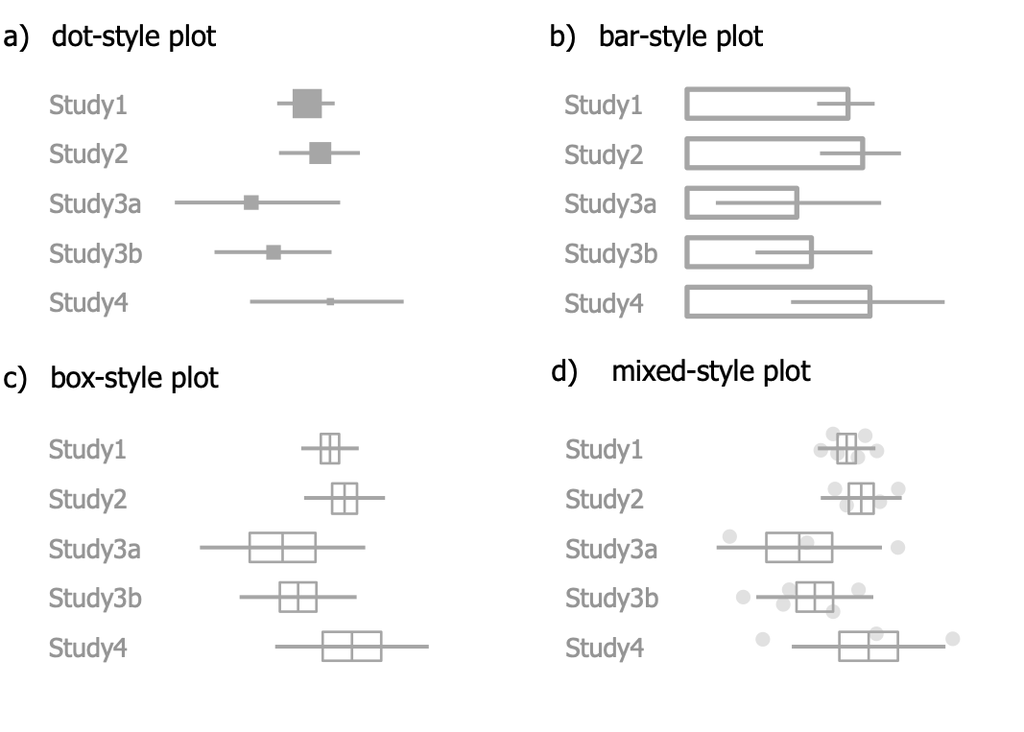

*Figure 1. Main graphical styles of forest-like plots.*

We also coded point estimates type (individual effect size for non-aggregated data / mean – mean value of aggregated effect sizes / median – median value of aggregated effect sizes / mixed – combination of any of the above, e.g., both aggregated and individual data points presented alongside, as in the proposed orchard plot), other/uncertain – cannot be easily classified as any of the above (discuss or exclude later), interval estimates type (CI – confidence interval or credible intervals / PI – prediction intervals (note that prediction intervals are also known as “credibility intervals”) / SD or SE – standard deviations or standard errors / mixed – combination of any of the above, e.g., both CI and PI are presented) and whether point/shape was of variable size due to scaling (unscaled – all points/dots/shapes are same size / scaled – points/dots/shapes have variable sizes to represent some additional point property, e.g., sample size / mixed – combination of any of the above, e.g., both unscaled and scaled points/dots/shapes are presented).

Two researchers (ML, JR) assessed extracted figures and classified their properties. They discussed and resolved any disagreements in the coded data.

We processed the coded data to create a paper-level table, with one consensus record per table, with information that allowed us to answer the questions outlined above.

## Literature survey - STAGE1 - Results

Data loading and preprocessing. Prepocessed data is presented in Extended Data Table 2.

```r
# getting the data and formating some variables (turning chraracter vectors
# to factors)
full_data <- read_excel("../data/Data collection for the _orchard plot_ manuscript (Responses)_cleaning2_ML.xlsx",
    na = "NA") %>% mutate_if(is.character, as.factor)
# str(full_data) #each row represents one scoring attempt, so it is usually
# 2 rows per figure file (since 2 people were assessing independently)
```

**Extended Data Table 2:** Preprocessed dataset from the literature survey of 102 meta-analytic papers in ecology or evolution.

```r
# making a scrollable table
kable(dat, "html") %>% kable_styling("striped", position = "left") %>% scroll_box(width = "100%",
    height = "300px")
```

| paperID | fileID | panel | panel_comm | aggr | aggr_comm | style | style_comm | point | point_comm | interv | interv_comm | scaling | scaling_comm | comm |
| --- | --- | --- | --- | --- | --- | --- | --- | --- | --- | --- | --- | --- | --- | --- |
| ft003 | ft003_fig1 | only one panel | NA | other_aggr | NA | dot | NA | meanES | NA | CI | NA | notscaled | NA | NA |
| ft008 | ft008_fig3 | only one panel | NA | other_aggr | NA | dot | NA | meanES | NA | CI | NA | notscaled | NA | NA |
| ft008 | ft008_fig4 | A, B | NA | other_aggr | NA | dot | NA | meanES | NA | CI | NA | notscaled | NA | NA |
| ft008 | ft008_fig5b | only one panel | NA | other_aggr | NA | dot | NA | meanES | NA | CI | NA | notscaled | NA | NA |
| ft008 | ft008_figS4.1 | only one panel | NA | other_aggr | NA | dot | NA | meanES | NA | CI | NA | notscaled | NA | NA |
| ft008 | ft008_figS4.2 | A, B | NA | other_aggr | NA | dot | NA | meanES | NA | CI | NA | notscaled | NA | not a forest plot? |
| ft009 | ft009_fig2 | A, B, C, D | NA | other_aggr | NA | other | short line used for the pint estimate | meanES | NA | other | no interval shown | notscaled | NA | NA |
| ft009 | ft009_figS1 | A, B | NA | other_aggr | NA | other | short line | meanES | NA | other | no interval | notscaled | NA | NA |
| ft011 | ft011_fig1 | only one panel | NA | other_aggr | NA | dot | NA | meanES | NA | CI | NA | notscaled | NA | NA |
| ft012 | ft012_fig3 | only one panel | NA | taxon | NA | dot | NA | meanES | NA | CI | NA | notscaled | NA | NA |
| ft012 | ft012_fig4 | only one panel | NA | other_aggr | NA | dot | NA | meanES | NA | CI | NA | notscaled | NA | NA |
| ft018 | ft018_fig2 | A, B, C | NA | other_aggr | NA | mixed | taxonomic / functional | meanES | NA | CI | NA | notscaled | NA | NA |
| ft018 | ft018_fig3 | A, B, C | NA | other_aggr | NA | dot | NA | meanES | NA | CI | NA | notscaled | NA | NA |
| ft019 | ft019_fig1 | only one panel | two panels but not labelled | other_aggr | NA | dot | NA | meanES | NA | CI | NA | notscaled | NA | NA |
| ft019 | ft019_fig2 | only one panel | two panels, not labelled | other_aggr | NA | dot | NA | meanES | NA | CI | NA | notscaled | NA | NA |
| ft019 | ft019_fig3 | only one panel | tow panels, but not labelled | other_aggr | NA | dot | NA | meanES | NA | CI | NA | notscaled | NA | NA |
| ft019 | ft019_fig4 | only one panel | two panels, but not labelled | other_aggr | NA | dot | NA | meanES | NA | CI | NA | notscaled | NA | NA |
| ft021 | ft021_fig1 | only one panel | NA | other_aggr | NA | dot | NA | meanES | NA | CI | NA | notscaled | NA | NA |
| ft021 | ft021_fig2 | only one panel | NA | other_aggr | NA | dot | NA | meanES | NA | CI | NA | notscaled | NA | NA |
| ft021 | ft021_fig3 | only one panel | NA | other_aggr | NA | dot | NA | meanES | NA | CI | NA | notscaled | NA | NA |
| ft021 | ft021_fig4 | only one panel | NA | other_aggr | NA | dot | NA | meanES | NA | CI | NA | notscaled | NA | NA |
| ft024 | ft024_fig1 | only one panel | NA | taxon | NA | dot | NA | meanES | NA | CI | NA | notscaled | NA | NA |
| ft024 | ft024_fig2 | only one panel | NA | other_aggr | NA | dot | NA | meanES | NA | CI | NA | notscaled | NA | NA |
| ft024 | ft024_fig3 | only one panel | NA | other_aggr | NA | dot | NA | meanES | NA | CI | NA | notscaled | NA | NA |
| ft024 | ft024_fig4 | only one panel | NA | other_aggr | NA | dot | NA | meanES | NA | CI | NA | notscaled | NA | NA |
| ft024 | ft024_fig5 | only one panel | NA | taxon | NA | dot | NA | meanES | NA | CI | NA | notscaled | NA | NA |
| ft025 | ft025_fig1 | only one panel | NA | other_aggr | NA | dot | NA | meanES | NA | CI | NA | notscaled | NA | NA |
| ft025 | ft025_fig2 | only one panel | NA | other_aggr | NA | dot | NA | meanES | NA | CI | NA | notscaled | NA | NA |
| ft025 | ft025_fig3 | only one panel | NA | other_aggr | NA | dot | NA | meanES | NA | CI | NA | notscaled | NA | NA |
| ft025 | ft025_figS2 | only one panel | NA | other_aggr | NA | dot | NA | meanES | NA | CI | NA | notscaled | NA | NA |

[output cut: 265 more lines]

### 1. How many papers present some form of forest plots?

**Answer 1.**  
Forest plots are commonly used in ecology and evolution - 83 papers (81.37%, out of 102 surveyed papers ) had at least one forest plot-like figure.

### 2. How many papers present prediction interval in forest plots?

```r
dat2 <- dat
# table(dat2$interv) table(dat2$interv_comm)

# group the dataset by paperID and create sets of papers that use CI
papers_CI_pure <- dat2 %>% filter(grepl("CI", interv)) %>% group_by(paperID) %>%
    summarise(CI1 = unique(paperID))  #71 papers
papers_CI_mix <- dat2 %>% filter(grepl("CI", interv_comm)) %>% group_by(paperID) %>%
    summarise(CI2 = unique(paperID))  #1 paper
papers_CI <- (union(papers_CI_pure$CI1, papers_CI_mix$CI2))  #72 papers with either pure or/and mix CI in the forest plots

# group the dataset by paperID and create sets of papers that use PI
papers_PI_pure <- dat2 %>% filter(grepl("PI", interv)) %>% group_by(paperID) %>%
    summarise(PI1 = unique(paperID))  #1 paper
papers_PI_mix <- dat2 %>% filter(grepl("PI", interv_comm)) %>% group_by(paperID) %>%
    summarise(PI2 = unique(paperID))  #0 papers
papers_PI <- (union(papers_PI_pure$PI1, papers_PI_mix$PI2))  #1 paper with either pure or/and mix PI in the forest plots

# group the dataset by paperID and create sets of papers that use SDorSE
papers_SDorSE_pure <- dat2 %>% filter(grepl("SDorSE", interv)) %>% group_by(paperID) %>%
    summarise(SDorSE1 = unique(paperID))  #7 papers
papers_SDorSE_mix <- dat2 %>% filter(grepl("SDorSE", interv_comm)) %>% group_by(paperID) %>%
    summarise(SDorSE2 = unique(paperID))  #0 papers
papers_SDorSE <- (union(papers_SDorSE_pure$SDorSE1, papers_SDorSE_mix$SDorSE2))  #7 papers with either pure or/and mix SDorSE in the forest plots
```

**Answer 2.**  
Only one (ft078; Fig.3) paper presented prediction interval in a forest plot (0.98%). Most commonly, as expected, confidence or credible intervals were used - 71 papers (69.61%). Occasionally, also SD or SE were presented - 7 papers (6.86%).

Reference of the paper with PI:

```r
# making a scrollable table
dat2table <- papers_data %>% filter(fulltext_ID %in% papers_PI) %>% select(fulltext_ID,
    authors, pub_year, title, journal, volume, pages)

# making a scrollable table
kable(dat2table, "html") %>% kable_styling("striped", position = "left") %>%
    scroll_box(width = "100%", height = "100px")
```

| fulltext_ID | authors | pub_year | title | journal | volume | pages |
| --- | --- | --- | --- | --- | --- | --- |
| ft078 | Davidson K.E., Fowler M.S., Skov M.W., Doerr S.H., Beaumont N., Griffin J.N. | 2017 | Livestock grazing alters multiple ecosystem properties and services in salt marshes: a meta-analysis | Journal Of Applied Ecology | 54 | 1395-1405 |

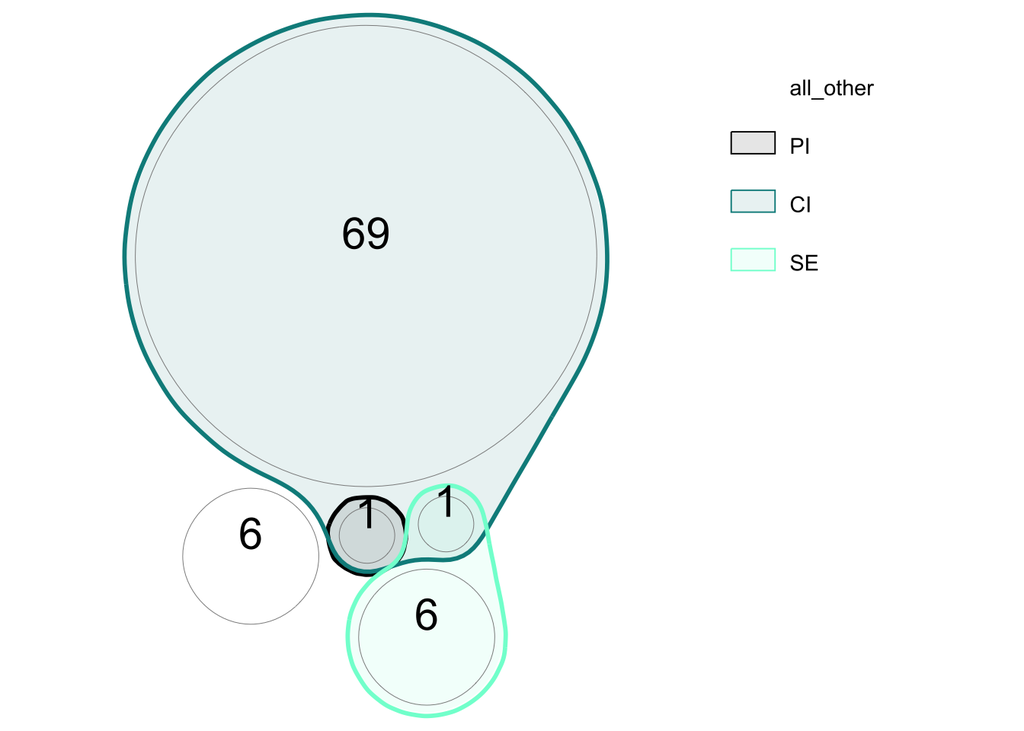

```r
myVaggr2 <- plotVenn(list(all_other = all, PI = papers_PI, CI = papers_CI, SE = papers_SDorSE),
    nCycles = 6000)  #, outFile = 'myVaggr.svg'
myVaggr2 <- plotVenn(nVennObj = myVaggr2)  #re-run simulation
# showSVG(nVennObj = myVaggr2, opacity = 0.1, borderWidth = 3)
showSVG(nVennObj = myVaggr2, opacity = 0.1, labelRegions = F, fontScale = 3,
    setColors = c("white", "black", "darkcyan", "aquamarine", "red"), borderWidth = 3)  # hiding region labels, big fonts, thick borders and custom colors
```

*Figure 2. Types of intervals used in surveyed papers.*  
*Legend description (numbers of papers with at least one plot with given feature):*  
PI = papers with PI used in forest(-like) plots (N = 1)  
CI = papers with CI used in forest(-like) plots (N = 71)  
SE = papers with SE or SE used in forest(-like) plots (N = 7)  
all_other = all other papers with forest(-like) plots

### 3a. What is most/least prevalent graphical style of forest plot used?

```r
dat2 <- dat
# table(dat2$style) table(dat2$style_comm)

# group the dataset by paperID and create sets of papers that use dot
papers_dot_pure <- dat2 %>% filter(grepl("dot", style)) %>% group_by(paperID) %>%
    summarise(dot1 = unique(paperID))  #80 papers
papers_dot_mix <- dat2 %>% filter(grepl("dot", style_comm)) %>% group_by(paperID) %>%
    summarise(dot2 = unique(paperID))  #5 papers
papers_dot <- (union(papers_dot_pure$dot1, papers_dot_mix$dot2))  #81 papers with either pure or/and mix dot  in the forest plots

# group the dataset by paperID and create sets of papers that use bar
papers_bar_pure <- dat2 %>% filter(grepl("bar", style)) %>% group_by(paperID) %>%
    summarise(bar1 = unique(paperID))  #3 papers
papers_bar_mix <- dat2 %>% filter(grepl("bar", style_comm)) %>% group_by(paperID) %>%
    summarise(bar2 = unique(paperID))  #1 paper
papers_bar <- (union(papers_bar_pure$bar1, papers_bar_mix$bar2))  #4 papers with either pure or/and mix bar in the forest plots

# group the dataset by paperID and create sets of papers that use box
papers_box_pure <- dat2 %>% filter(grepl("box", style)) %>% group_by(paperID) %>%
    summarise(box1 = unique(paperID))  #4 papers
papers_box_mix <- dat2 %>% filter(grepl("box", style_comm)) %>% group_by(paperID) %>%
    summarise(box2 = unique(paperID))  #3 papers
papers_box <- (union(papers_box_pure$box1, papers_box_mix$box2))  #6 papers with either pure or/and mix box in the forest plots
```

**Answer 3a.**  
Here we looked at the main graphical plot styles: dot/box/bar. As expected, “dot” was by far the most popular - 80 papers (78.43%), as this is the “classic” forest plot style (a shape is used to represent point estimate along with CI presented as whiskers, i.e. line). There were small numbers of papers with bar plots - 4 papers (3.92%) and box plots - 6 papers (5.88%).

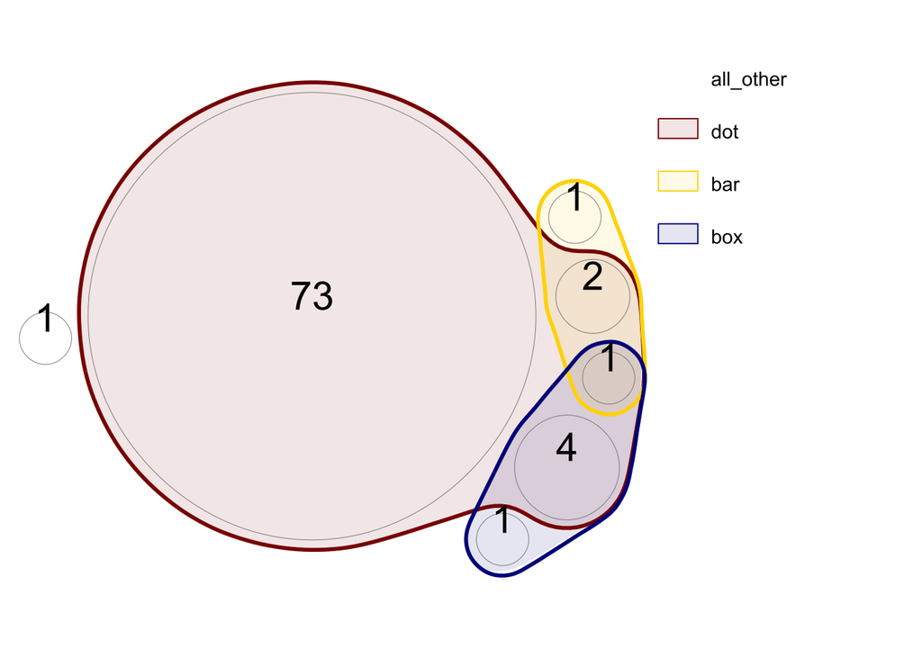

```r
myVaggr3a <- plotVenn(list(all_other = all, dot = papers_dot, bar = papers_bar,
    box = papers_box), nCycles = 6000)  #, outFile = 'myVaggr.svg'
myVaggr3a <- plotVenn(nVennObj = myVaggr3a)  #re-run simulation
# showSVG(nVennObj = myVaggr3a, opacity = 0.1, borderWidth = 3)
showSVG(nVennObj = myVaggr3a, opacity = 0.1, labelRegions = F, fontScale = 3,
    setColors = c("white", "darkred", "gold", "darkblue"), borderWidth = 3)  # hiding region labels, big fonts, thick borders and custom colors
```

*Figure 3. Graphical styles used in surveyed papers.*  
*Legend description (numbers of papers with at least one plot with given feature):*  
dot = papers with dot-type style of forest(-like) plots (N = 80)  
bar = papers with bar-type style of forest(-like) plots (N = 4)  
box = papers with box-type style of forest(-like) plots (N = 6)  
all_other = all other papers with forest(-like) plots

### 3b. How often is size scaling of point estimates used in forest plots?

```r
dat2 <- dat
# table(dat2$scaling) table(dat2$scaling_comm)

# group the dataset by paperID and create sets of papers that use dot
papers_scaling_pure <- dat2 %>% filter(scaling == "scaled") %>% group_by(paperID) %>%
    summarise(scaling1 = unique(paperID))  #15 papers
papers_scaling_mix <- dat2 %>% filter(grepl("scale", scaling_comm)) %>% group_by(paperID) %>%
    summarise(scaling2 = unique(paperID))  #1 paper
papers_scaling <- (union(papers_scaling_pure$scaling1, papers_scaling_mix$scaling2))  #16 papers with dot scaling in the forest plots
```

**Answer 3b.**  
Here we looked at whether dot shapes are scaled to represent their properties (sample sizes, precision, etc.) Only 16 papers (15.69 %; 20 % of papers with dot-style plots), used point estimate scaling in their forest plots.

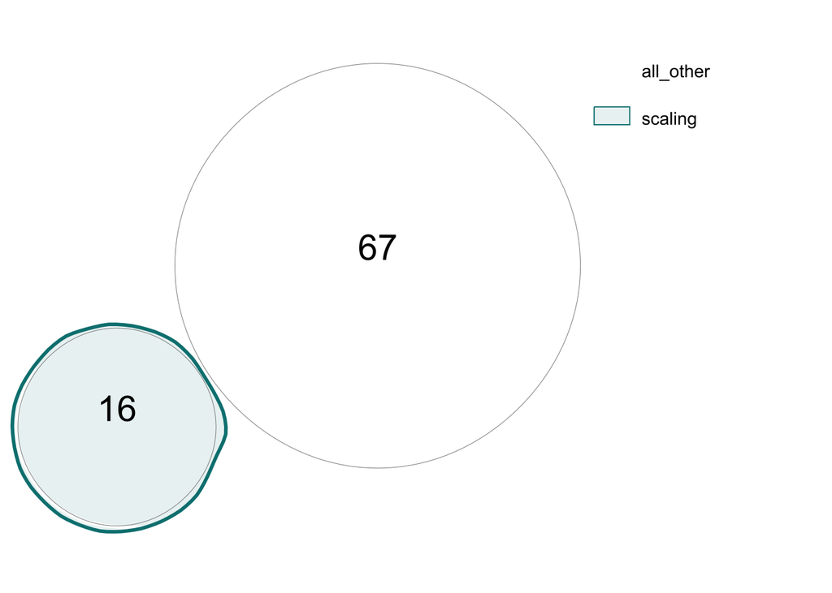

```r
myVaggr3b <- plotVenn(list(all_other = all, scaling = papers_scaling), nCycles = 6000)  #, outFile = 'myVaggr.svg'
myVaggr3b <- plotVenn(nVennObj = myVaggr3b)  #re-run simulation
# showSVG(nVennObj = myVaggr3b, opacity = 0.1, borderWidth = 3)
showSVG(nVennObj = myVaggr3b, opacity = 0.1, labelRegions = F, fontScale = 3,
    setColors = c("white", "teal"), borderWidth = 3)  # hiding region labels, big fonts, thick borders and custom colors
```

### 4. What are the frequencies of presenting of aggregated data in the forest plot at the study, taxon, or other levels? How often non-aggregated data is presented?

```r
dat2 <- dat
# table(dat2$aggr) table(dat2$aggr_comm)

# group the dataset by paperID and create sets of papers that use taxon
papers_taxon_pure <- dat2 %>% filter(grepl("taxon", aggr)) %>% group_by(paperID) %>%
    summarise(taxon1 = unique(paperID))  #15 papers
papers_taxon_mix <- dat2 %>% filter(grepl("taxon", aggr_comm)) %>% group_by(paperID) %>%
    summarise(taxon2 = unique(paperID))  #16 papers
papers_taxon <- (union(papers_taxon_pure$taxon1, papers_taxon_mix$taxon2))  #27 papers with either pure or/and mix taxon aggregation in the forest plots

# group the dataset by paperID and create sets of papers that use study
papers_study_pure <- dat2 %>% filter(grepl("study", aggr)) %>% group_by(paperID) %>%
    summarise(study1 = unique(paperID))  #12 papers
papers_study_mix <- dat2 %>% filter(grepl("study", aggr_comm)) %>% group_by(paperID) %>%
    summarise(study2 = unique(paperID))  #5 papers
papers_study <- (union(papers_study_pure$study1, papers_study_mix$study2))  #15 papers with either pure or/and mix study aggregation in the forest plots

# group the dataset by paperID and create sets of papers that use individual
papers_individual_pure <- dat2 %>% filter(grepl("individual", aggr)) %>% group_by(paperID) %>%
    summarise(individual1 = unique(paperID))  #4 papers
papers_individual_mix <- dat2 %>% filter(grepl("individual", aggr_comm)) %>%
    group_by(paperID) %>% summarise(individual2 = unique(paperID))  #7 papers
papers_individual <- (union(papers_individual_pure$individual1, papers_individual_mix$individual2))  #10 papers with either pure or/and mix individual aggregation in the forest plots

# group the dataset by paperID and create sets of papers that use other
papers_other_pure <- dat2 %>% filter(grepl("other", aggr)) %>% group_by(paperID) %>%
    summarise(other1 = unique(paperID))  #68 papers
papers_other_mix <- dat2 %>% filter(grepl("other", aggr_comm)) %>% group_by(paperID) %>%
    summarise(other2 = unique(paperID))  #19 papers
papers_other <- (union(papers_other_pure$other1, papers_other_mix$other2))  #77 papers with either pure or/and mix other aggregation in the forest plots
```

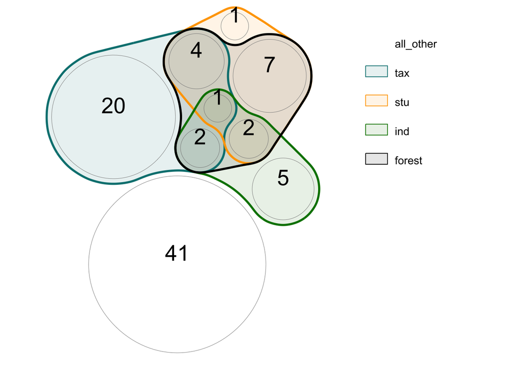

```r
# myVaggr4 <- plotVenn(list(all_papers=all, taxon_aggr = papers_taxon,
# study_aggr=papers_study, individual_aggr=papers_individual), nCycles =
# 6000) #, outFile = 'myVaggr.svg' myVaggr4 <- plotVenn(nVennObj = myVaggr4)
# #re-run simulation #showSVG(nVennObj = myVaggr4, opacity = 0.1,
# borderWidth = 3) showSVG(nVennObj = myVaggr4, opacity = 0.1, labelRegions
# = F, fontScale = 3, setColors = c('white', 'teal', 'orange', 'green',
# 'black'), borderWidth = 3) # hiding region labels, big fonts, thick
# borders and custom colors

# with hand-picked 'potential forest' paper added (in balck):
potential_forest <- c("ft037", "ft065", "ft078", "ft082", "ft084", "ft098",
    "ft109", "ft112", "ft131", "ft148", "ft151", "ft167", "ft173", "ft175",
    "ft177", "ft181")

myVaggr4 <- plotVenn(list(all_other = all, tax = papers_taxon, stu = papers_study,
    ind = papers_individual, forest = potential_forest), nCycles = 6000)  #, outFile = 'myVaggr.svg'
myVaggr4 <- plotVenn(nVennObj = myVaggr4)  #re-run simulation
showSVG(nVennObj = myVaggr4, opacity = 0.1, labelRegions = F, fontScale = 3,
    setColors = c("white", "teal", "orange", "green", "black"), borderWidth = 3)  # hiding region labels, big fonts, thick borders and custom colors
```

*Figure 5. Aggregation levels used in surveyed papers.*  
*Legend description (numbers of papers with at least one plot with given feature):*  
tax = papers with effect sizes aggregated to taxon level in the forest(-like) plots (N = 27)  
stu = papers with effect sizes aggregated to study level in the forest(-like) plots (N = 15)  
ind = papers with individual effect sizes presented in the forest(-like) plots (N = 10)  
forest = potential papers with “classic/real” forest-plots (to be manually re-evaluated) (N = 16)  
all_other = all other papers with forest(-like) plots

Table of papers with potential classic forest plots (to be re-evaluated to see if they are actually can be considered “classic” forest plots):

```r
# making a scrollable table
dat4table <- papers_data %>% filter(fulltext_ID %in% potential_forest) %>% select(fulltext_ID,
    authors, pub_year, title, journal, volume, pages)

# making a scrollable table
kable(dat4table, "html") %>% kable_styling("striped", position = "left") %>% scroll_box(width = "100%",
    height = "500px")
```

| fulltext_ID | authors | pub_year | title | journal | volume | pages |
| --- | --- | --- | --- | --- | --- | --- |
| ft037 | Loydi A., Eckstein R.L., Otte A., Donath T.W. | 2013 | Effects of litter on seedling establishment in natural and semi-natural grasslands: a meta-analysis | Journal Of Ecology | 101 | 454-464 |
| ft065 | Slatyer R.A., Hirst M., Sexton J.P. | 2013 | Niche breadth predicts geographical range size: a general ecological pattern | Ecology Letters | 16 | 1104-1114 |
| ft078 | Davidson K.E., Fowler M.S., Skov M.W., Doerr S.H., Beaumont N., Griffin J.N. | 2017 | Livestock grazing alters multiple ecosystem properties and services in salt marshes: a meta-analysis | Journal Of Applied Ecology | 54 | 1395-1405 |
| ft082 | Merkling T., Nakagawa S., Lagisz M., Schwanz L.E. | 2018 | Maternal testosterone and offspring sex-ratio in birds and mammals: a meta-analysis | Evolutionary Biology | 45 | 96-104 |
| ft084 | Veresoglou S.D., Rillig M.C. | 2012 | Suppression of fungal and nematode plant pathogens through arbuscular mycorrhizal fungi | Biology Letters | 8 | 214-217 |
| ft098 | Barrio I.C., Hik D.S., Bueno C.G., Cahill J.F. | 2013 | Extending the stress-gradient hypothesis - is competition among animals less common in harsh environments? | Oikos | 122 | 516-523 |
| ft109 | ÄŒapek P., Manzoni S., KaÅ¡tovská E., Wild B., Diáková K., Bárta J., Schnecker J., Biasi C., Martikainen P.J., Alves R.J.E., Guggenberger G., Gentsch N., Hugelius G., Palmtag J., Mikutta R., Shibi… | 2018 | A plant–microbe interaction framework explaining nutrient effects on primary production | Nature Ecology & Evolution | 2 | 1588-1596 |
| ft112 | Miller S.E., Barrueto M., Schluter D. | 2017 | A comparative analysis of experimental selection on the stickleback pelvis | Journal Of Evolutionary Biology | 30 | 1165-1176 |
| ft131 | Karban R., Yang L.H., Edwards K.F. | 2014 | Volatile communication between plants that affects herbivory: a meta-analysis | Ecology Letters | 17 | 44-52 |
| ft148 | Smith R.K., Pullin A.S., Stewart G.B., Sutherl and W.J. | 2011 | Is nest predator exclusion an effective strategy for enhancing bird populations? | Biological Conservation | 144 | 42277 |
| ft151 | Dobler R., Rogell B., Budar F., Dowling D.K. | 2014 | A meta-analysis of the strength and nature of cytoplasmic genetic effects | Journal Of Evolutionary Biology | 27 | 2021-2034 |
| ft167 | Rifkin J.L., Nunn C.L., Garamszegi L.Z. | 2012 | Do animals living in larger groups experience greater parasitism? A meta-analysis | American Naturalist | 180 | 70-82 |
| ft173 | Des Roches S., Post D.M., Turley N.E., Bailey J.K., Hendry A.P., Kinnison M.T., Schweitzer J.A., Palkovacs E.P. | 2018 | The ecological importance of intraspecific variation | Nature Ecology & Evolution | 2 | 57-64 |
| ft175 | O’Brien J.M., Scheibling R.E. | 2018 | Turf wars: competition between foundation and turf-forming species on temperate and tropical reefs and its role in regime shifts | Marine Ecology Progress Series | 590 | 41274 |
| ft177 | Sánchez C.A., Becker D.J., Teitelbaum C.S., Barriga P., Brown L.M., Majewska A.A., Hall R.J., Altizer S. | 2018 | On the relationship between body condition and parasite infection in wildlife: a review and meta-analysis | Ecology Letters | 21 | 1869-1884 |
| ft181 | Lehmann A., Zheng W., Rillig M.C. | 2017 | Soil biota contributions to soil aggregation | Nature Ecology & Evolution | 1 | 1828-1835 |

### 5. What is the frequency of “classic/original” forest plots?

We re-evaluated the subset of 16 papers with potential “original/classic” forest plots.  
We used the following definition of “classic/original” forest plot:  
*Graphical representation of all individual effect sizes used in a meta-analysis (i.e. a meta-analytic/meta-regression models), as well as their overall mean, presented in a single panel, using a dot + interval plot style.*

**Answer 5.**  
Out of 16 papers re-assessed, 12 contained “original/classic” forest plots (see table below for the references).

```r
# 1. ft065 (ft065_fig1.png, ft065_fig2.png, ft065_fig3.png) 2. ft078
# (ft078_figS1.png) 3. ft082 (ft082_figS4.png) 4. ft098 (ft098_fig2.png) 5 ft112
# (ft112_fig2.png, ft112_fig3.png, ft112_figS3.png, ft112_figS4.png,
# ft112_figS5.png) 6. ft131 (ft131_fig1.png) 7 ft148 (ft148_figS2.png,
# ft148_figS4.png, ft148_figS7.png, ft148_figS10.png, ft148_figS18.png,
# ft148_figS19.png) # 8. ft151 (ft151_fig1.png) 9. ft167 (ft167_fig2.png,
# ft167_figSB.png) 10. ft173 (ft173_fig2.png) 11. ft175 (ft175_figS4.png,
# ft175_figS5.png, ft175_figS6.png, ft175_figS7.png) 12. ft177 (ft177_fig2.png)

real_forest <- c("ft065", "ft078", "ft082", "ft098", "ft112", "ft131", "ft148", "ft151",
    "ft167", "ft173", "ft175", "ft177")

dat5table <- papers_data %>% filter(fulltext_ID %in% real_forest) %>% select(fulltext_ID,
    authors, pub_year, title, journal, volume, pages)

# making a scrollable table of references
kable(dat5table, "html") %>% kable_styling("striped", position = "left") %>% scroll_box(width = "100%",
    height = "500px")
```

| fulltext_ID | authors | pub_year | title | journal | volume | pages |
| --- | --- | --- | --- | --- | --- | --- |
| ft065 | Slatyer R.A., Hirst M., Sexton J.P. | 2013 | Niche breadth predicts geographical range size: a general ecological pattern | Ecology Letters | 16 | 1104-1114 |
| ft078 | Davidson K.E., Fowler M.S., Skov M.W., Doerr S.H., Beaumont N., Griffin J.N. | 2017 | Livestock grazing alters multiple ecosystem properties and services in salt marshes: a meta-analysis | Journal Of Applied Ecology | 54 | 1395-1405 |
| ft082 | Merkling T., Nakagawa S., Lagisz M., Schwanz L.E. | 2018 | Maternal testosterone and offspring sex-ratio in birds and mammals: a meta-analysis | Evolutionary Biology | 45 | 96-104 |
| ft098 | Barrio I.C., Hik D.S., Bueno C.G., Cahill J.F. | 2013 | Extending the stress-gradient hypothesis - is competition among animals less common in harsh environments? | Oikos | 122 | 516-523 |
| ft112 | Miller S.E., Barrueto M., Schluter D. | 2017 | A comparative analysis of experimental selection on the stickleback pelvis | Journal Of Evolutionary Biology | 30 | 1165-1176 |
| ft131 | Karban R., Yang L.H., Edwards K.F. | 2014 | Volatile communication between plants that affects herbivory: a meta-analysis | Ecology Letters | 17 | 44-52 |
| ft148 | Smith R.K., Pullin A.S., Stewart G.B., Sutherl and W.J. | 2011 | Is nest predator exclusion an effective strategy for enhancing bird populations? | Biological Conservation | 144 | 42277 |
| ft151 | Dobler R., Rogell B., Budar F., Dowling D.K. | 2014 | A meta-analysis of the strength and nature of cytoplasmic genetic effects | Journal Of Evolutionary Biology | 27 | 2021-2034 |
| ft167 | Rifkin J.L., Nunn C.L., Garamszegi L.Z. | 2012 | Do animals living in larger groups experience greater parasitism? A meta-analysis | American Naturalist | 180 | 70-82 |
| ft173 | Des Roches S., Post D.M., Turley N.E., Bailey J.K., Hendry A.P., Kinnison M.T., Schweitzer J.A., Palkovacs E.P. | 2018 | The ecological importance of intraspecific variation | Nature Ecology & Evolution | 2 | 57-64 |
| ft175 | O’Brien J.M., Scheibling R.E. | 2018 | Turf wars: competition between foundation and turf-forming species on temperate and tropical reefs and its role in regime shifts | Marine Ecology Progress Series | 590 | 41274 |
| ft177 | SÃ¡nchez C.A., Becker D.J., Teitelbaum C.S., Barriga P., Brown L.M., Majewska A.A., Hall R.J., Altizer S. | 2018 | On the relationship between body condition and parasite infection in wildlife: a review and meta-analysis | Ecology Letters | 21 | 1869-1884 |

The remaining 4 re-assessed papers were excluded due to not showing the overall mean effect size in the same plot panel.

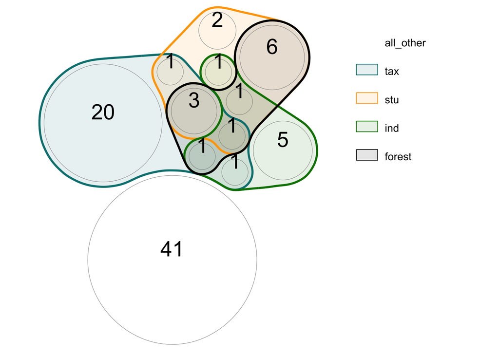

```r
# with hand-picked 'real forest' paper added (in balck):
myVaggr5 <- plotVenn(list(all_other = all, tax = papers_taxon, stu = papers_study,
    ind = papers_individual, forest = real_forest), nCycles = 6000)  #, outFile = 'myVaggr.svg'
myVaggr5 <- plotVenn(nVennObj = myVaggr5)  #re-run simulation
showSVG(nVennObj = myVaggr5, opacity = 0.1, labelRegions = F, fontScale = 3,
    setColors = c("white", "teal", "orange", "green", "black"), borderWidth = 3)  # hiding region labels, big fonts, thick borders and custom colors
```

*Figure 6. aggregation levels in surveyed papers relatively to papers with classic forest plots.*  
*Legend description (numbers of papers with at least one plot with given feature):*  
tax = papers with effect sizes aggregated to taxon level in the forest(-like) plots (N = 27)  
stu = papers with effect sizes aggregated to study level in the forest(-like) plots (N = 15)  
ind = papers with individual effect sizes presented in the forest(-like) plots (N = 10)  
forest = actual papers with “classic/real” forest-plots (manually re-evaluated) (N = 12)  
all_other = all other papers with forest(-like) plots

## Literature survey STAGE1 - extra

### 6. What is the frequency of forest-like plots with species as aggregation levels?

To answer this question we re-evaluated a subset of 27 papers which used some sort of taxonomic grouping for aggregating effect sizes. We then created a list of papers containing at least one plot with species-level aggregation of effect sizes. IDs of re-evaluated papers: ft012, ft024, ft028, ft029, ft036, ft041, ft044, ft045, ft056, ft060, ft062, ft068, ft082, ft084, ft088, ft095, ft104, ft117, ft126, ft131, ft140, ft148, ft150, ft173, ft177, ft181, ft187

**Answer 6.**  
Final list of 7 papers presenting “species” forest-like plots:

```r
# 1. ft024 (ft024_fig1.png, ft024_fig5.png) 2. ft028 (ft140_figS1.png) 3.
# ft060 (ft060_fig2.png (a)) 4. ft068 (ft068_fig2.png) 5. ft117
# (ft117_fig2.png, ft117_figS1.png, ft117_figS2.png, ft117_figS3.png) 6.
# ft140 (ft140_fig3.png (a)) 7. ft187 (ft187_fig1.png (a), ft187_figS1.png,
# ft187_figS2.png, ft187_figS3.png)

papers_species <- c("ft024", "ft028", "ft060", "ft068", "ft117", "ft140", "ft187")

dat6 <- dat %>% filter(paperID %in% papers_species) %>% select(paperID, fileID,
    scaling) %>% group_by(paperID) %>% summarise(figures = paste(fileID, collapse = ", ",
    scaling))

# making a scrollable table
dat6table <- papers_data %>% filter(fulltext_ID %in% papers_species) %>% select(fulltext_ID,
    authors, pub_year, title, journal, volume, pages)

kable(dat6table, "html") %>% kable_styling("striped", position = "left") %>%
    scroll_box(width = "100%", height = "300px")
```

fulltext_ID

authors

pub_year

title

journal

volume

pages

ft024

Felker-Quinn E., Schweitzer J.A., Bailey J.K.

2013

Meta-analysis reveals evolution in invasive plant species but little support for evolution of increased competitive ability (eica)

Ecology And Evolution

3

739-751

ft028

Kamiya T., O’Dwyer K., Westerdahl H., Senior A., Nakagawa S.

2014

A quantitative review of mhc-based mating preference: the role of diversity and dissimilarity

Molecular Ecology

23

5151-5163

ft060

Hector K.L., Lagisz M., Nakagawa S.

2012

The effect of resveratrol on longevity across species: a meta-analysis

Biology Letters

8

790-793

ft068

Halupka L., Halupka K.

2017

The effect of climate change on the duration of avian breeding seasons: a meta-analysis

Proceedings Of The Royal Society B: Biological Sciences

284

ft117

Ord T.J., King L., Young A.R.

2011

Contrasting theory with the empirical data of species recognition

Evolution

65

2572-2591

ft140

Zvereva E.L., Kozlov M.V.

2012

Sources of variation in plant responses to belowground insect herbivory: a meta-analysis

Oecologia

169

441-452

ft187

Greenfield M.D., Alem S., Limousin D., Bailey N.W.

2014

The dilemma of fisherian sexual selection: mate choice for indirect benefits despite rarity and overall weakness of trait-preference genetic correlation

Evolution

68

3524-3536

The remaining assessed papers were excluded due to aggregation of effect sizes at higher taxonomic levels than species. Notable special cases: ft084 - figures present mixture of species and higher taxonomic levels; ft131 - figures present aggregation is at both species and study level, i.e. no single estimate per species.

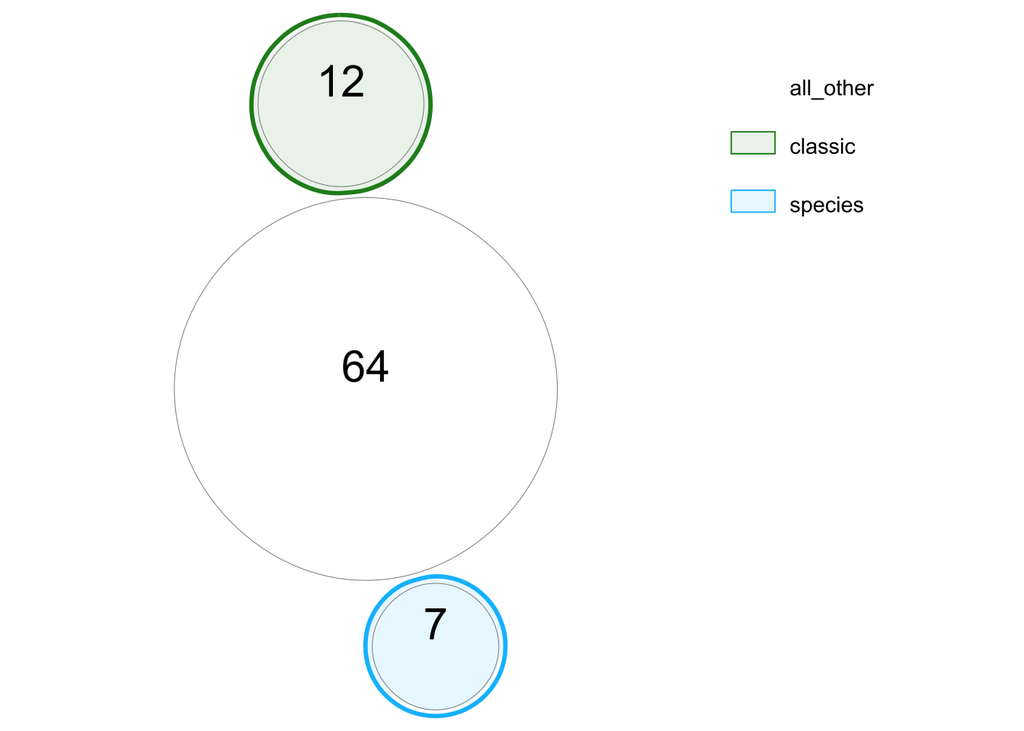

```r
all <- unique(dat$paperID)  #IDs of all papers

myVaggr6 <- plotVenn(list(all_other = all, classic = real_forest, species = papers_species),
    nCycles = 6000)  #, outFile = 'myVaggr.svg'
myVaggr6 <- plotVenn(nVennObj = myVaggr6)  #re-run simulation
showSVG(nVennObj = myVaggr6, opacity = 0.1, labelRegions = F, fontScale = 3, setColors = c("white",
    "forestgreen", "deepskyblue"), borderWidth = 3)  # hiding region labels, big fonts, thick borders and custom colors
```

*Figure 7. Species-level aggregation in surveyed papers.*  
*Legend description (numbers of papers with at least one plot with given feature):*  
species = papers with effect sizes aggregated to species level in the forest(-like) plots (N = 7)  
classic = actual papers with “classic/real” forest-plots (manually re-evaluated) (N = 12)  
all_other = all other papers with forest(-like) plots

### 7. What is the frequency of forest-like plots with individual effect sizes overlaid as dots over aggregated effect estimates? Are these individual dots scaled to the effect size (e.g., using sample size, precision)?

To answer this question, we re-evaluated a subset of 10 papers which had presented some sort of individual effect size in forest plots (other that presenting effect sizes by study). We then created a list of papers containing at least one plot with individual effect sizes presented as dots overlaid over estimates of aggregated effect sizes. IDs of re-evaluated papers: ft039, ft066, ft078, ft096, ft109, ft120, ft121, ft148, ft177, ft181

**Answer 7.**  
Final list of references of papers presenting “overlaid” forest-like plots:

```r
# 1. ft039 (ft096_fig3.png (odd, with box plots)) - individual effect size
# dots not scaled 2. ft096 (ft096_fig1.png, ft096_fig2.png, ft096_figS2.png,
# ft096_figS3.png, ft096_figS4.png, ft096_figS5.png) - individual effect
# size dots scaled 3. ft181 (ft181_fig2.png, ft181_fig3.png, ft181_fig4.png)
# - individual effect size dots not scaled


papers_overlaid <- c("ft039", "ft096", "ft181")

# making a scrollable table
dat7table <- papers_data %>% filter(fulltext_ID %in% papers_overlaid) %>% select(fulltext_ID,
    authors, pub_year, title, journal, volume, pages)

# making a scrollable table
kable(dat7table, "html") %>% kable_styling("striped", position = "left") %>%
    scroll_box(width = "100%", height = "500px")
```

| fulltext_ID | authors | pub_year | title | journal | volume | pages |
| --- | --- | --- | --- | --- | --- | --- |
| ft039 | Slot M., Kitajima K. | 2015 | General patterns of acclimation of leaf respiration to elevated temperatures across biomes and plant types | Oecologia | 177 | 885-900 |
| ft096 | Moore M.P., Riesch R., Martin R.A. | 2016 | The predictability and magnitude of life-history divergence to ecological agents of selection: a meta-analysis in livebearing fishes | Ecology Letters | 19 | 435-442 |
| ft181 | Lehmann A., Zheng W., Rillig M.C. | 2017 | Soil biota contributions to soil aggregation | Nature Ecology & Evolution | 1 | 1828-1835 |

The remaining papers were excluded due to all relevant figures not showing individual effect sizes as dots overlayed onto aggregated effect sizes.

## Literature survey - STAGE2

We re-assessed forest-like plots with “aggregated effect sizes” to record how often overall mean is presented alongside aggregated effect sizes and how aggregated effect sizes are calculated.

Additional questions to be answered in STAGE2 coding:  
8. Do forest-like plots present an overall meta-analytic mean?  
9. Do forest-like plots present point estimates calculated separately for subsets of data (as in medical “summary forest plot”, where a meta-analytic model is run for each subset of effect sizes and meta-analytic mean for the subset is presented, so called “subgroup analysis” in medicine) or these point estimates are based on meta-regressions models (i.e. model of all data with a moderator(s)).

Predictions: we expected to find a mixture of forest-like plots (based on meta-regressions, without overall mean) and summary forest plots (based on subgroup analyses, often with overall mean) in ecological and evolutionary meta-analyses. Summary forest plots could be considered a special case of the forest-like plots.

During STAGE2, two researchers (ML, YY) assessed the extracted figures that were earlier classified as presenting forest plot-like aggregated effect estimates. They classified additional properties of these plots: whether overall meta-analytic mean was presented in the same plot (for each relevant figure panel). The pilot coding was done on 10 randomly selected figures, then YY conducted main extraction of all figures, with all labelled as other/unsure at any point, checked and discussed with ML.

```r
# length(all) #all 83 paper IDs length(dat$fileID) #all file IDs = 296
classic_IDs <- c("ft065_fig1", "ft065_fig2.png", "ft065_fig3.png", "ft078_figS1",
    "ft082_figS4", "ft098_fig2", "ft112_fig2", "112_fig3", "112_figS3", "112_figS4",
    "112_figS5", "ft131_fig1", "ft148_figS2", "148_figS4", "148_figS7", "148_figS10",
    "148_figS18", "148_figS19", "ft151_fig1", "ft167_fig2", "167_figSB", "ft173_fig2",
    "ft175_figS4", "175_figS5", "175_figS6", "175_figS7", "ft177_fig2")

files_individual_pure <- c("ft109_figS10", "ft109_figS12", "ft109_figS13", "ft109_figS14",
    "ft109_figS9", "ft120_fig4", "ft121_fig1", "ft148_figS10")

# exclude 'classic' forest plots and 'individual' forest plots
toasses <- setdiff(dat$fileID, classic_IDs)
toasses <- setdiff(toasses, files_individual_pure)

dat7 <- dat %>% filter(fileID %in% toasses) %>% select(paperID, fileID) %>% group_by(paperID) %>%
    summarise(figures = paste(fileID, collapse = ", "))
dat7 <- dat7 %>% filter(paperID != "ft065")  #exclude ft065 - no aggregated forest plots there

# making a scrollable table
kable(dat7, "html") %>% kable_styling("striped", position = "left") %>% scroll_box(width = "100%",
    height = "300px")
```

[output not shown]

## Literature survey STAGE2 - results

```r
# getting the data and formating some variables (turning chraracter vectors
# to factors)
S2_data <- read_excel("../data/Data collection for the _orchard plot_ manuscript - STAGE2 (Responses)_cleaned.xlsx",
    na = "NA") %>% mutate_if(is.character, as.factor)
# str(S2_data) #each row represents one scoring attempt, so it is usually 2
# rows per figure file (since 2 people were assessing independently)

# remove all rows with censor==1, so that only one final score is left for
# each figure file
S2_data <- S2_data %>% filter(censor == 0)
S2_data <- droplevels(S2_data)  #adjust factor levels
```

Table of papers and specific figures re-assessed and coded in STAGE2 (N = 77 papers):

```r
# making a scrollable table
kable(S2_data, "html") %>% kable_styling("striped", position = "left") %>% scroll_box(width = "100%",
    height = "300px")
```

| paperID | fileID | N_panels | panel_comm | overall_mean | overall_mean_comm | aggr_estimate_by | aggr_estimate_by_comm | comm |
| --- | --- | --- | --- | --- | --- | --- | --- | --- |
| ft125 | ft125_fig2 | 2 | a | no | NA | meta-regression | unweigthed meta-regression equivalent | NA |
| ft125 | ft125_fig3 | 2 | a | no | NA | meta-regression | unweigthed meta-regression equivalent | NA |
| ft125 | ft125_fig4 | 1 | NA | no | NA | meta-regression | unweigthed meta-regression equivalent | NA |
| ft125 | ft125_fig5 | 2 | a | no | NA | meta-regression | unweigthed meta-regression equivalent | NA |
| ft125 | ft125_fig6 | 1 | NA | no | NA | meta-regression | unweigthed meta-regression equivalent | NA |
| ft125 | ft125_fig7 | 2 | a, b | no | NA | meta-regression | unweigthed meta-regression equivalent | NA |
| ft125 | ft125_fig8 | 2 | a, b | no | NA | meta-regression | unweigthed meta-regression equivalent | NA |
| ft003 | ft003_fig1 | 1 | NA | no | NA | meta-regression | model mentioned in caption and mixed effects model used in p2667: All meta-analyses were performed using generalized linear mixed models implemented in the R package MCMCglmm | NA |
| ft008 | ft008_fig3 | 1 | NA | no | NA | meta-regression | moderator (biome) as fixed effect in caption | NA |
| ft008 | ft008_fig4 | 2 | a, b | no | NA | meta-regression | moderator as the fixed effect in caption | NA |
| ft008 | ft008_fig5b | 1 | NA | no | NA | meta-regression | moderator as fixed effect and interaction analysis in caption | NA |
| ft008 | ft008_figS4.1 | 1 | NA | no | NA | meta-regression | moderator as fixed effect in caption | NA |
| ft008 | ft008_figS4.2 | 2 | a, b | no | NA | meta-regression | moderator as fixed effect and interaction mentioned in caption | NA |
| ft009 | ft009_fig2 | 4 | a, b, c, d | no | NA | meta-regression | moderator and mixed effect model mentioned in caption | NA |
| ft009 | ft009_figS1 | 2 | A, B | no | NA | meta-regression | moderator and mixed effect model mentioned in caption | NA |
| ft011 | ft011_fig1 | 1 | NA | no | NA | meta-regression | assumed meta-regression for the reason of between-study heterogenity mentioned in p.11004: We used between-group heterogeneity (Qbetween) to determine the differences in effect size between different … | NA |
| ft012 | ft012_fig4 | 1 | NA | no | NA | meta-regression | mixed models mentioned in p127-128: Each species-trait mean is modeled as the sum of a fixed factor that represents the effect of a category (e.g., taxon or trait category) and a random effect. | NA |
| ft018 | ft018_fig2 | 3 | a, b , c | no | NA | meta-regression | hierarchical models mentioned in p.127: We then fitted six hierarchical mixed-effects multiple metaregressions of z, one meta-regression using our (2003–2015) full dataset, four using subsets of our d… | NA |
| ft018 | ft018_fig3 | 3 | a, b, c | no | NA | meta-regression | hierarchical models mentioned in p.127: We then fitted six hierarchical mixed-effects multiple metaregressions of z, one meta-regression using our (2003–2015) full dataset, four using subsets of our d… | NA |
| ft019 | ft019_fig1 | 2 | a, b | no | NA | meta-regression | moderating variables and between study heterogeneisty mentioned in p.230: we examined the p values of the Qbetween statistics because we were interested in the variation in effect sizes due to differe… | NA |
| ft019 | ft019_fig1 | 2 | a, b | no | NA | meta-analysis | The previsou coding of this fig is wrong. This fig should be the meta-analytic overrall mean for four different traits. As mentied overall in caption and univariate data analysis in p.230 | NA |
| ft019 | ft019_fig2 | 2 | a, b | no | NA | meta-regression | moderating variables between study heterogneity were mentioned in p. 230: we examined the p values of the Qbetween statistics because we were interested in the variation in effect sizes due to differe… | NA |
| ft019 | ft019_fig3 | 2 | a, b | no | NA | meta-regression | moderating variables and between study heterogeneity mentioned in p230 | NA |
| ft019 | ft019_fig4 | 2 | a, b | no | NA | meta-regression | moderating variables and between study heterogeneity mentioned in p230 | NA |
| ft021 | ft021_fig1 | 1 | NA | no | NA | meta-regression | between-group heterogeneity mentioned in p.3: Differences in the percentage changes of the response variables between the two plant life-forms were tested by calculating between-group heterogeneity (Q… | NA |
| ft021 | ft021_fig3 | 1 | NA | no | NA | meta-regression | between-group heterogeneity mentioned in p.3: Differences in the percentage changes of the response variables between the two plant life-forms were tested by calculating between-group heterogeneity (Q… | NA |
| ft021 | ft021_fig4 | 1 | NA | no | NA | meta-regression | between-group heterogeneity mentioned in p.3: Differences in the percentage changes of the response variables between the two plant life-forms were tested by calculating between-group heterogeneity (Q… | NA |
| ft024 | ft024_fig1 | 1 | NA | yes | summary effect size presented in the top of the pane | meta-regression | it seems like a meta-regression. But very little info about meta-analysis were mentioned in full text | NA |
| ft024 | ft024_fig3 | 1 | NA | yes | on the top of the pane | meta-regression | it seems like a meta-regression. But very little info about meta-analysis were mentioned in full text | NA |
| ft024 | ft024_fig4 | 2 | a, b | no | NA | meta-regression | it seems like a meta-regression. But very little info about meta-analysis were mentioned in full text | NA |

[output cut: 221 more lines]

```r
S2_data1 <- S2_data
# table(S2_data1$overall_mean) table(S2_data1$overall_mean_comm)

# we want to do it per plot - need to add up number of panles per figure in
# each group each sum(S2_data1$N_panels) #607 plots assessed

# group the dataset by overall_mean type and create sets of papers for each
# one:
sum_overall_mean <- S2_data %>% # filter(overall_mean=='yes') %>%
group_by(overall_mean) %>% summarise(sum = sum(N_panels))
# sum(sum_overall_mean$sum)
sum_overall_mean$percent <- sum_overall_mean$sum/sum(sum_overall_mean$sum) *
    100  #add column with percentages
# sum_overall_mean

papers_with_overall_mean <- S2_data1 %>% filter(overall_mean == "yes") %>% group_by(paperID) %>%
    summarise(overall_mean = unique(paperID))
# dim(papers_with_overall_mean) #31 (out of 77) papers

papers_without_overall_mean <- S2_data1 %>% filter(overall_mean == "no") %>%
    group_by(paperID) %>% summarise(overall_mean = unique(paperID))
# dim(papers_without_overall_mean) #64 (out of 77) papers
# (nrow(papers_with_overall_mean) + nrow(papers_without_overall_mean) -
# length(unique(S2_data1$paperID)))/2 # 9 papers with both plots with and
# without overall mean
```

**Answer 8.**  
Overall mean is not commonly presented along aggregated point estimates in forest-like plots. It appears only in 135 (22.24%) out of 607 aggregated forest-like plots assessed. These plots were from 31 papers (30.39% of all papers).

Table of references of papers with aggregated forest-like plots with overall mean:

```r
# making a scrollable table
dat8table <- papers_data %>% filter(fulltext_ID %in% papers_with_overall_mean$paperID) %>%
    select(fulltext_ID, authors, pub_year, title, journal, volume, pages)

# making a scrollable table
kable(dat8table, "html") %>% kable_styling("striped", position = "left") %>%
    scroll_box(width = "100%", height = "500px")
```

fulltext_ID

authors

pub_year

title

journal

volume

pages

ft024

Felker-Quinn E., Schweitzer J.A., Bailey J.K.

2013

Meta-analysis reveals evolution in invasive plant species but little support for evolution of increased competitive ability (eica)

Ecology And Evolution

3

739-751

ft025

Ma C., Li S.P., Pu Z., Tan J., Liu M., Zhou J., Li H., Jiang L.

2016

Different effects of invader-native phylogenetic relatedness on invasion success and impact: a meta-analysis of darwinâ€™s naturalization hypothesis

Proceedings Of The Royal Society B: Biological Sciences

283

ft027

Murphy G.E.P., Romanuk T.N.

2014

A meta-analysis of declines in local species richness from human disturbances

Ecology And Evolution

4

91-103

ft028

Kamiya T., O’Dwyer K., Westerdahl H., Senior A., Nakagawa S.

2014

A quantitative review of mhc-based mating preference: the role of diversity and dissimilarity

Molecular Ecology

23

5151-5163

ft029

Conord C., Gurevitch J., Fady B.

2012

Large-scale longitudinal gradients of genetic diversity: a meta-analysis across six phyla in the mediterranean basin

Ecology And Evolution

2

2600-2614

ft036

Shantz A.A., Lemoine N.P., Burkepile D.E.

2016

Nutrient loading alters the performance of key nutrient exchange mutualisms

Ecology Letters

19

20-28

ft037

Loydi A., Eckstein R.L., Otte A., Donath T.W.

2013

Effects of litter on seedling establishment in natural and semi-natural grasslands: a meta-analysis

Journal Of Ecology

101

454-464

ft044

Garamszegi L.Z., MarkÃ³ G., Herczeg G.

2012

A meta-analysis of correlated behaviours with implications for behavioural syndromes: mean effect size, publication bias, phylogenetic effects and the role of mediator variables

Evolutionary Ecology

26

1213-1235

ft060

Hector K.L., Lagisz M., Nakagawa S.

2012

The effect of resveratrol on longevity across species: a meta-analysis

Biology Letters

8

790-793

ft082

Merkling T., Nakagawa S., Lagisz M., Schwanz L.E.

2018

Maternal testosterone and offspring sex-ratio in birds and mammals: a meta-analysis

Evolutionary Biology

45

96-104

ft084

Veresoglou S.D., Rillig M.C.

2012

Suppression of fungal and nematode plant pathogens through arbuscular mycorrhizal fungi

Biology Letters

8

214-217

ft088

Harvey B.P., Gwynn-Jones D., Moore P.J.

2013

Meta-analysis reveals complex marine biological responses to the interactive effects of ocean acidification and warming

Ecology And Evolution

3

1016-1030

ft093

English S., Uller T.

2016

Does early-life diet affect longevity? A meta-analysis across experimental studies

Biology Letters

12

ft095

Kornder N.A., Riegl B.M., Figueiredo J.

2018

Thresholds and drivers of coral calcification responses to climate change

Global Change Biology

24

5084-5095

ft105

Mundim F.M., Bruna E.M.

2016

Is there a temperate bias in our understanding of how climate change will alter plant-herbivore interactions? A meta-analysis of experimental studies

American Naturalist

188

S74-S89

ft110

Smith R.K., Pullin A.S., Stewart G.B., Sutherl and W.J.

2010

Effectiveness of predator removal for enhancing bird populations [efectividad de la remociÃ³n de depredadores para incrementar las poblaciones de aves]

Conservation Biology

24

820-829

ft112

Miller S.E., Barrueto M., Schluter D.

2017

A comparative analysis of experimental selection on the stickleback pelvis

Journal Of Evolutionary Biology

30

1165-1176

ft117

Ord T.J., King L., Young A.R.

2011

Contrasting theory with the empirical data of species recognition

Evolution

65

2572-2591

ft122

Sorenson G.H., Dey C.J., Madliger C.L., Love O.P.

2017

Effectiveness of baseline corticosterone as a monitoring tool for fitness: a meta-analysis in seabirds

Oecologia

183

353-365

ft126

Edge C.B., Houlahan J.E., Jackson D.A., Fortin M.-J.

2016

The response of amphibian larvae to environmental change is both consistent and variable

Oikos

125

1700-1711

ft131

Karban R., Yang L.H., Edwards K.F.

2014

Volatile communication between plants that affects herbivory: a meta-analysis

Ecology Letters

17

44-52

ft134

Barton K.E., Koricheva J.

2010

The ontogeny of plant defense and herbivory: characterizing general patterns using meta-analysis

American Naturalist

175

481-493

ft135

Koricheva J., Romero G.Q.

2012

You get what you pay for: reward-specific trade-offs among direct and ant-mediated defences in plants

Biology Letters

8

628-630

ft144

Xi N., Zhang C., Bloor J.M.G.

2017

Species richness alters spatial nutrient heterogeneity effects on above-ground plant biomass

Biology Letters

13

ft155

Ma Z., Chen H.Y.H.

2016

Effects of species diversity on fine root productivity in diverse ecosystems: a global meta-analysis

Global Ecology And Biogeography

25

1387-1396

ft165

Singh A., Punzalan D.

2018

The strength of sex-specific selection in the wild

Evolution

NA

ft166

Murphy G.E.P., Romanuk T.N.

2012

A meta-analysis of community response predictability to anthropogenic disturbances

American Naturalist

180

316-327

ft173

Des Roches S., Post D.M., Turley N.E., Bailey J.K., Hendry A.P., Kinnison M.T., Schweitzer J.A., Palkovacs E.P.

2018

The ecological importance of intraspecific variation

Nature Ecology & Evolution

2

57-64

ft174

Breed M.F., Ottewell K.M., Gardner M.G., Marklund M.H., Dormontt E.E., Lowe A.J.

2015

Mating patterns and pollinator mobility are critical traits in forest fragmentation genetics

Heredity

115

108-114

ft181

Lehmann A., Zheng W., Rillig M.C.

2017

Soil biota contributions to soil aggregation

Nature Ecology & Evolution

1

1828-1835

ft187

Greenfield M.D., Alem S., Limousin D., Bailey N.W.

2014

The dilemma of fisherian sexual selection: mate choice for indirect benefits despite rarity and overall weakness of trait-preference genetic correlation

Evolution

68

3524-3536

Table of references of papers with aggregated forest-like plots without overall mean:

```r
# making a scrollable table
dat8table <- papers_data %>% filter(fulltext_ID %in% papers_without_overall_mean$paperID) %>%
    select(fulltext_ID, authors, pub_year, title, journal, volume, pages)

# making a scrollable table
kable(dat8table, "html") %>% kable_styling("striped", position = "left") %>%
    scroll_box(width = "100%", height = "500px")
```

fulltext_ID

authors

pub_year

title

journal

volume

pages

ft003

Prokop Z.M., Michalczyk L., Drobniak S.M., Herdegen M., Radwan J.

2012

Meta-analysis suggests choosy females get sexy sons more than “good genes”

Evolution

66

2665-2673

ft008

Greenwood S., Ruiz-Benito P., Martínez-Vilalta J., Lloret F., Kitzberger T., Allen C.D., Fensham R., Laughlin D.C., Kattge J., Bönisch G., Kraft N.J.B., Jump A.S.

2017

Tree mortality across biomes is promoted by drought intensity, lower wood density and higher specific leaf area

Ecology Letters

20

539-553

ft009

Murren C.J., Maclean H.J., Diamond S.E., Steiner U.K., Heskel M.A., H and elsman C.A., Ghalambor C.K., Auld J.R., Callahan H.S., Pfennig D.W., Relyea R.A., Schlichting C.D., Kingsolver J.

2014

Evolutionary change in continuous reaction norms

American Naturalist

183

453-467

ft011

Eziz A., Yan Z., Tian D., Han W., Tang Z., Fang J.

2017

Drought effect on plant biomass allocation: a meta-analysis

Ecology And Evolution

7

11002-11010

ft012

Jiang Y., Bolnick D.I., Kirkpatrick M.

2013

Assortative mating in animals

American Naturalist

181

E125-E138

ft018

Kinlock N.L., Prowant L., Herstoff E.M., Foley C.M., Akin-Fajiye M., Bender N., Umarani M., Ryu H.Y., Åžen B., Gurevitch J.

2018

Explaining global variation in the latitudinal diversity gradient: meta-analysis confirms known patterns and uncovers new ones

Global Ecology And Biogeography

27

125-141

ft019

Vranckx G., Jacquemyn H., Muys B., Honnay O.

2012

Meta-analysis of susceptibility of woody plants to loss of genetic diversity through habitat fragmentation

Conservation Biology

26

228-237

ft021

Li F.-R., Peng S.-L., Chen B.-M., Hou Y.-P.

2010

A meta-analysis of the responses of woody and herbaceous plants to elevated ultraviolet-b radiation

Oecologia

36

42247

ft024

Felker-Quinn E., Schweitzer J.A., Bailey J.K.

2013

Meta-analysis reveals evolution in invasive plant species but little support for evolution of increased competitive ability (eica)

Ecology And Evolution

3

739-751

ft025

Ma C., Li S.P., Pu Z., Tan J., Liu M., Zhou J., Li H., Jiang L.

2016

Different effects of invader-native phylogenetic relatedness on invasion success and impact: a meta-analysis of darwinâ€™s naturalization hypothesis

Proceedings Of The Royal Society B: Biological Sciences

283

ft027

Murphy G.E.P., Romanuk T.N.

2014

A meta-analysis of declines in local species richness from human disturbances

Ecology And Evolution

4

91-103

ft028

Kamiya T., O’Dwyer K., Westerdahl H., Senior A., Nakagawa S.

2014

A quantitative review of mhc-based mating preference: the role of diversity and dissimilarity

Molecular Ecology

23

5151-5163

ft029

Conord C., Gurevitch J., Fady B.

2012

Large-scale longitudinal gradients of genetic diversity: a meta-analysis across six phyla in the mediterranean basin

Ecology And Evolution

2

2600-2614

ft030

RowiÅ„ski P.K., Rogell B.

2017

Environmental stress correlates with increases in both genetic and residual variances: a meta-analysis of animal studies

Evolution

71

1339-1351

ft032

Voje K.L.

2015

Scaling of morphological characters across trait type, sex, and environment: a meta-analysis of static allometries

American Naturalist

187

89-98

ft037

Loydi A., Eckstein R.L., Otte A., Donath T.W.

2013

Effects of litter on seedling establishment in natural and semi-natural grasslands: a meta-analysis

Journal Of Ecology

101

454-464

ft039

Slot M., Kitajima K.

2015

General patterns of acclimation of leaf respiration to elevated temperatures across biomes and plant types

Oecologia

177

885-900

ft040

Przeslawski R., Byrne M., Mellin C.

2015

A review and meta-analysis of the effects of multiple abiotic stressors on marine embryos and larvae

Global Change Biology

21

2122-2140

ft041

Pietsch K.A., Ogle K., Cornelissen J.H.C., Cornwell W.K., BÃ¶nisch G., Craine J.M., Jackson B.G., Kattge J., Peltzer D.A., Penuelas J., Reich P.B., Wardle D.A., Weedon J.T., Wright I.J., Zanne A.E., Wirth C.

2014

Global relationship of wood and leaf litter decomposability: the role of functional traits within and across plant organs

Global Ecology And Biogeography

23

1046-1057

ft045

Bateman D.C., Bishop M.J.

2017

The environmental context and traits of habitat-forming bivalves influence the magnitude of their ecosystem engineering

Marine Ecology Progress Series

563

95-110

ft047

McLean M.J., Bishop P.J., Nakagawa S.

2012

Male quality, signal reliability and female choice: assessing the expectations of inter-sexual selection

Journal Of Evolutionary Biology

25

1513-1520

ft055

Chaplin-Kramer R., O’Rourke M.E., Blitzer E.J., Kremen C.

2011

A meta-analysis of crop pest and natural enemy response to landscape complexity

Ecology Letters

14

922-932

ft056

Batáry P., Báldi A., Kleijn D., Tscharntke T.

2011

Landscape-moderated biodiversity effects of agri-environmental management: a meta-analysis

Proceedings Of The Royal Society B: Biological Sciences

278

1894-1902

ft060

Hector K.L., Lagisz M., Nakagawa S.

2012

The effect of resveratrol on longevity across species: a meta-analysis

Biology Letters

8

790-793

ft062

Caruso C.M., Martin R.A., Sletvold N., Morrissey M.B., Wade M.J., Augustine K.E., Carlson S.M., Maccoll A.D.C., Siepielski A.M., Kingsolver J.G.

2017

What are the environmental determinants of phenotypic selection? A meta-analysis of experimental studies

American Naturalist

190

363-376

ft066

Jactel H., Gritti E.S., DrÃ¶ssler L., Forrester D.I., Mason W.L., Morin X., Pretzsch H., Castagneyrol B.

2018

Positive biodiversityâ€“productivity relationships in forests: climate matters

Biology Letters

14

ft067

Moatt J.P., Nakagawa S., Lagisz M., Walling C.A.

2016

The effect of dietary restriction on reproduction: a meta-analytic perspective

Bmc Evolutionary Biology

16

42247

ft068

Halupka L., Halupka K.

2017

The effect of climate change on the duration of avian breeding seasons: a meta-analysis

Proceedings Of The Royal Society B: Biological Sciences

284

ft074

van Katwijk M.M., Thorhaug A., MarbÃ N., Orth R.J., Duarte C.M., Kendrick G.A., Althuizen I.H.J., Balestri E., Bernard G., Cambridge M.L., Cunha A., Durance C., Giesen W., Han Q., Hosokawa S., Kiswara W., Komatsu T., Lardicci C., Lee K.-S., Meinesz A., Nakaoka M., O’Brien K.R., Paling E.I., Pickerell C., Ransijn A.M.A., Verduin J.J.

2016

Global analysis of seagrass restoration: the importance of large-scale planting

Journal Of Applied Ecology

53

567-578

ft075

Temme A.A., Cornwell W.K., Cornelissen J.H.C., Aerts R.

2013

Meta-analysis reveals profound responses of plant traits to glacial co2 levels

Ecology And Evolution

3

4525-4535

ft077

De Boeck H.J., Bloor J.M.G., Kreyling J., Ransijn J.C.G., Nijs I., Jentsch A., Zeiter M.

2018

Patterns and drivers of biodiversityâ€“stability relationships under climate extremes

Journal Of Ecology

106

890-902

ft078

Davidson K.E., Fowler M.S., Skov M.W., Doerr S.H., Beaumont N., Griffin J.N.

2017

Livestock grazing alters multiple ecosystem properties and services in salt marshes: a meta-analysis

Journal Of Applied Ecology

54

1395-1405

ft084

Veresoglou S.D., Rillig M.C.

2012

Suppression of fungal and nematode plant pathogens through arbuscular mycorrhizal fungi

Biology Letters

8

214-217

ft088

Harvey B.P., Gwynn-Jones D., Moore P.J.

2013

Meta-analysis reveals complex marine biological responses to the interactive effects of ocean acidification and warming

Ecology And Evolution

3

1016-1030

ft089

Fuzessy L.F., Cornelissen T.G., Janson C., Silveira F.A.O.

2016

How do primates affect seed germination? A meta-analysis of gut passage effects on neotropical plants

Oikos

125

1069-1080

ft090

Thurman T.J., Barrett R.D.H.

2016

The genetic consequences of selection in natural populations

Molecular Ecology

25

1429-1448

ft092

MazÃa N., Moyano J., Perez L., Aguiar S., Garibaldi L.A., Schlichter T.

2016

The sign and magnitude of treeâ€“grass interaction along a global environmental gradient

Global Ecology And Biogeography

25

1510-1519

ft095

Kornder N.A., Riegl B.M., Figueiredo J.

2018

Thresholds and drivers of coral calcification responses to climate change

Global Change Biology

24

5084-5095

ft096

Moore M.P., Riesch R., Martin R.A.

2016

The predictability and magnitude of life-history divergence to ecological agents of selection: a meta-analysis in livebearing fishes

Ecology Letters

19

435-442

ft104

Wood J.L.A., Yates M.C., Fraser D.J.

2016

Are heritability and selection related to population size in nature? Meta-analysis and conservation implications

Evolutionary Applications

9

640-657

ft109

ÄŒapek P., Manzoni S., KaÅ¡tovská E., Wild B., Diáková K., Bárta J., Schnecker J., Biasi C., Martikainen P.J., Alves R.J.E., Guggenberger G., Gentsch N., Hugelius G., Palmtag J., Mikutta R., Shibistova O., Urich T., Schleper C., Richter A., Å antrÅ¯Äková H.

2018

A plantâ€“microbe interaction framework explaining nutrient effects on primary production

Nature Ecology & Evolution

2

1588-1596

ft110

Smith R.K., Pullin A.S., Stewart G.B., Sutherl and W.J.

2010

Effectiveness of predator removal for enhancing bird populations [efectividad de la remociÃ³n de depredadores para incrementar las poblaciones de aves]

Conservation Biology

24

820-829

ft112

Miller S.E., Barrueto M., Schluter D.

2017

A comparative analysis of experimental selection on the stickleback pelvis

Journal Of Evolutionary Biology

30

1165-1176

ft115

Bourdeau P.E., Butlin R.K., BrÃ¶nmark C., Edgell T.C., Hoverman J.T., Holl and er J.

2015

What can aquatic gastropods tell us about phenotypic plasticity? A review and meta-analysis

Heredity

115

312-321

ft117

Ord T.J., King L., Young A.R.

2011

Contrasting theory with the empirical data of species recognition

Evolution

65

2572-2591

ft125

Vogwill T., Maclean R.C.

2015

The genetic basis of the fitness costs of antimicrobial resistance: a meta-analysis approach

Evolutionary Applications

8

284-295

ft127

Edwards K.F., Aquilino K.M., Best R.J., Sellheim K.L., Stachowicz J.J.

2010

Prey diversity is associated with weaker consumer effects in a meta-analysis of benthic marine experiments

Ecology Letters

13

194-201

ft133

Zvereva E.L., Kozlov M.V.

2014

Effects of herbivory on leaf life span in woody plants: a meta-analysis

Journal Of Ecology

102

873-881

ft134

Barton K.E., Koricheva J.

2010

The ontogeny of plant defense and herbivory: characterizing general patterns using meta-analysis

American Naturalist

175

481-493

ft137

Rosa R., Rummer J.L., Munday P.L.

2017

Biological responses of sharks to ocean acidification

Biology Letters

13

ft139

Pearson D.E., Ortega Y.K., Runyon J.B., Butler J.L.

2016

Secondary invasion: the bane of weed management

Biological Conservation

197

41486

ft140

Zvereva E.L., Kozlov M.V.

2012

Sources of variation in plant responses to belowground insect herbivory: a meta-analysis

Oecologia

169

441-452

ft143

Massad T.J.

2013

Ontogenetic differences of herbivory on woody and herbaceous plants: a meta-analysis demonstrating unique effects of herbivory on the young and the old, the slow and the fast

Oecologia

172

42277

ft144

Xi N., Zhang C., Bloor J.M.G.

2017

Species richness alters spatial nutrient heterogeneity effects on above-ground plant biomass

Biology Letters

13

ft148

Smith R.K., Pullin A.S., Stewart G.B., Sutherl and W.J.

2011

Is nest predator exclusion an effective strategy for enhancing bird populations?

Biological Conservation

144

42277

ft150

Caruso C.M., Eisen K.E., Martin R.A., Sletvold N.

2019

A meta-analysis of the agents of selection on floral traits

Evolution

73

40268

ft151

Dobler R., Rogell B., Budar F., Dowling D.K.

2014

A meta-analysis of the strength and nature of cytoplasmic genetic effects

Journal Of Evolutionary Biology

27

2021-2034

ft163

Barto E.K., Rillig M.C.

2010

Does herbivory really suppress mycorrhiza? A meta-analysis

Journal Of Ecology

98

745-753

ft165

Singh A., Punzalan D.

2018

The strength of sex-specific selection in the wild

Evolution

NA

ft166

Murphy G.E.P., Romanuk T.N.

2012

A meta-analysis of community response predictability to anthropogenic disturbances

American Naturalist

180

316-327

ft175

O’Brien J.M., Scheibling R.E.

2018

Turf wars: competition between foundation and turf-forming species on temperate and tropical reefs and its role in regime shifts

Marine Ecology Progress Series

590

41274

ft177

SÃ¡nchez C.A., Becker D.J., Teitelbaum C.S., Barriga P., Brown L.M., Majewska A.A., Hall R.J., Altizer S.

2018

On the relationship between body condition and parasite infection in wildlife: a review and meta-analysis

Ecology Letters

21

1869-1884

ft181

Lehmann A., Zheng W., Rillig M.C.

2017

Soil biota contributions to soil aggregation

Nature Ecology & Evolution

1

1828-1835

ft188

De Kort H., V and epitte K., Honnay O.

2013

A meta-analysis of the effects of plant traits and geographical scale on the magnitude of adaptive differentiation as measured by the difference between qst and fst

Evolutionary Ecology

27

1081-1097

```r
S2_data2 <- S2_data
# table(S2_data2$aggr_estimate_by) table(S2_data2$aggr_estimate_by_comm)

# we want to do it per plot - need to add up number of panles per figure in
# each group each sum(S2_data2$N_panels) #607 plots assessed

# group the dataset by overall_mean type and create sets of papers for each
# one:
sum_aggr_estimate_by <- S2_data2 %>% # filter(aggr_estimate_by=='meta-analysis') %>%
group_by(aggr_estimate_by) %>% summarise(sum = sum(N_panels))
# sum(sum_overall_mean$sum)
sum_aggr_estimate_by$percent <- sum_aggr_estimate_by$sum/sum(sum_aggr_estimate_by$sum) *
    100  #add column with percentages

papers_with_metaregression <- S2_data2 %>% filter(aggr_estimate_by == "meta-regression") %>%
    group_by(paperID) %>% summarise(sum_aggr_estimate_by = unique(paperID))
# dim(papers_with_metaregression) #73 (out of 77) papers

papers_with_metaanalysis <- S2_data2 %>% filter(aggr_estimate_by == "meta-analysis") %>%
    group_by(paperID) %>% summarise(overall_mean = unique(paperID))
# dim(papers_with_metaanalysis) #14 (out of 77) papers
# (nrow(papers_with_metaregression) + nrow(papers_with_metaanalysis) -
# length(unique(S2_data2$paperID)))/2 # 9 papers with both plots with
# meta-analysis and meta-regression
```

**Answer 9.**  
Most commonly, forest-like plots in ecology and evolution are based on meta-regression models - 562 (92.59%) out of 607 aggregated forest-like plots assessed. These plots were from 73 papers (71.57% of all papers).

Table of references of papers with aggregated forest-like plots based on meta-regression models:

```r
# making a scrollable table
dat9table <- papers_data %>% filter(fulltext_ID %in% papers_with_metaregression$paperID) %>%
    select(fulltext_ID, authors, pub_year, title, journal, volume, pages)

# making a scrollable table
kable(dat9table, "html") %>% kable_styling("striped", position = "left") %>%
    scroll_box(width = "100%", height = "500px")
```

fulltext_ID

authors

pub_year

title

journal

volume

pages

ft003

Prokop Z.M., Michalczyk L., Drobniak S.M., Herdegen M., Radwan J.

2012

Meta-analysis suggests choosy females get sexy sons more than “good genes”

Evolution

66

2665-2673

ft008

Greenwood S., Ruiz-Benito P., Martínez-Vilalta J., Lloret F., Kitzberger T., Allen C.D., Fensham R., Laughlin D.C., Kattge J., Bönisch G., Kraft N.J.B., Jump A.S.

2017

Tree mortality across biomes is promoted by drought intensity, lower wood density and higher specific leaf area

Ecology Letters

20

539-553

ft009

Murren C.J., Maclean H.J., Diamond S.E., Steiner U.K., Heskel M.A., H and elsman C.A., Ghalambor C.K., Auld J.R., Callahan H.S., Pfennig D.W., Relyea R.A., Schlichting C.D., Kingsolver J.

2014

Evolutionary change in continuous reaction norms

American Naturalist

183

453-467

ft011

Eziz A., Yan Z., Tian D., Han W., Tang Z., Fang J.

2017

Drought effect on plant biomass allocation: a meta-analysis

Ecology And Evolution

7

11002-11010

ft012

Jiang Y., Bolnick D.I., Kirkpatrick M.

2013

Assortative mating in animals

American Naturalist

181

E125-E138

ft018

Kinlock N.L., Prowant L., Herstoff E.M., Foley C.M., Akin-Fajiye M., Bender N., Umarani M., Ryu H.Y., Åžen B., Gurevitch J.

2018

Explaining global variation in the latitudinal diversity gradient: meta-analysis confirms known patterns and uncovers new ones

Global Ecology And Biogeography

27

125-141

ft019

Vranckx G., Jacquemyn H., Muys B., Honnay O.

2012

Meta-analysis of susceptibility of woody plants to loss of genetic diversity through habitat fragmentation

Conservation Biology

26

228-237

ft021

Li F.-R., Peng S.-L., Chen B.-M., Hou Y.-P.

2010

A meta-analysis of the responses of woody and herbaceous plants to elevated ultraviolet-b radiation

Oecologia

36

42247

ft024

Felker-Quinn E., Schweitzer J.A., Bailey J.K.

2013

Meta-analysis reveals evolution in invasive plant species but little support for evolution of increased competitive ability (eica)

Ecology And Evolution

3

739-751

ft025

Ma C., Li S.P., Pu Z., Tan J., Liu M., Zhou J., Li H., Jiang L.

2016

Different effects of invader-native phylogenetic relatedness on invasion success and impact: a meta-analysis of darwinâ€™s naturalization hypothesis

Proceedings Of The Royal Society B: Biological Sciences

283

ft027

Murphy G.E.P., Romanuk T.N.

2014

A meta-analysis of declines in local species richness from human disturbances

Ecology And Evolution

4

91-103

ft028

Kamiya T., O’Dwyer K., Westerdahl H., Senior A., Nakagawa S.

2014

A quantitative review of mhc-based mating preference: the role of diversity and dissimilarity

Molecular Ecology

23

5151-5163

ft029

Conord C., Gurevitch J., Fady B.

2012

Large-scale longitudinal gradients of genetic diversity: a meta-analysis across six phyla in the mediterranean basin

Ecology And Evolution

2

2600-2614

ft030

RowiÅ„ski P.K., Rogell B.

2017

Environmental stress correlates with increases in both genetic and residual variances: a meta-analysis of animal studies

Evolution

71

1339-1351

ft032

Voje K.L.

2015

Scaling of morphological characters across trait type, sex, and environment: a meta-analysis of static allometries

American Naturalist

187

89-98

ft036

Shantz A.A., Lemoine N.P., Burkepile D.E.

2016

Nutrient loading alters the performance of key nutrient exchange mutualisms

Ecology Letters

19

20-28

ft037

Loydi A., Eckstein R.L., Otte A., Donath T.W.

2013

Effects of litter on seedling establishment in natural and semi-natural grasslands: a meta-analysis

Journal Of Ecology

101

454-464

ft039

Slot M., Kitajima K.

2015

General patterns of acclimation of leaf respiration to elevated temperatures across biomes and plant types

Oecologia

177

885-900

ft040

Przeslawski R., Byrne M., Mellin C.

2015

A review and meta-analysis of the effects of multiple abiotic stressors on marine embryos and larvae

Global Change Biology

21

2122-2140

ft041

Pietsch K.A., Ogle K., Cornelissen J.H.C., Cornwell W.K., BÃ¶nisch G., Craine J.M., Jackson B.G., Kattge J., Peltzer D.A., Penuelas J., Reich P.B., Wardle D.A., Weedon J.T., Wright I.J., Zanne A.E., Wirth C.

2014

Global relationship of wood and leaf litter decomposability: the role of functional traits within and across plant organs

Global Ecology And Biogeography

23

1046-1057

ft044

Garamszegi L.Z., MarkÃ³ G., Herczeg G.

2012

A meta-analysis of correlated behaviours with implications for behavioural syndromes: mean effect size, publication bias, phylogenetic effects and the role of mediator variables

Evolutionary Ecology

26

1213-1235

ft045

Bateman D.C., Bishop M.J.

2017

The environmental context and traits of habitat-forming bivalves influence the magnitude of their ecosystem engineering

Marine Ecology Progress Series

563

95-110

ft047

McLean M.J., Bishop P.J., Nakagawa S.

2012

Male quality, signal reliability and female choice: assessing the expectations of inter-sexual selection

Journal Of Evolutionary Biology

25

1513-1520

ft055

Chaplin-Kramer R., O’Rourke M.E., Blitzer E.J., Kremen C.

2011

A meta-analysis of crop pest and natural enemy response to landscape complexity

Ecology Letters

14

922-932

ft056

Batáry P., Báldi A., Kleijn D., Tscharntke T.

2011

Landscape-moderated biodiversity effects of agri-environmental management: a meta-analysis

Proceedings Of The Royal Society B: Biological Sciences

278

1894-1902

ft060

Hector K.L., Lagisz M., Nakagawa S.

2012

The effect of resveratrol on longevity across species: a meta-analysis

Biology Letters

8

790-793

ft062

Caruso C.M., Martin R.A., Sletvold N., Morrissey M.B., Wade M.J., Augustine K.E., Carlson S.M., Maccoll A.D.C., Siepielski A.M., Kingsolver J.G.

2017

What are the environmental determinants of phenotypic selection? A meta-analysis of experimental studies

American Naturalist

190

363-376

ft066

Jactel H., Gritti E.S., DrÃ¶ssler L., Forrester D.I., Mason W.L., Morin X., Pretzsch H., Castagneyrol B.

2018

Positive biodiversityâ€“productivity relationships in forests: climate matters

Biology Letters

14

ft067

Moatt J.P., Nakagawa S., Lagisz M., Walling C.A.

2016

The effect of dietary restriction on reproduction: a meta-analytic perspective

Bmc Evolutionary Biology

16

42247

ft068

Halupka L., Halupka K.

2017

The effect of climate change on the duration of avian breeding seasons: a meta-analysis

Proceedings Of The Royal Society B: Biological Sciences

284

ft074

van Katwijk M.M., Thorhaug A., MarbÃ N., Orth R.J., Duarte C.M., Kendrick G.A., Althuizen I.H.J., Balestri E., Bernard G., Cambridge M.L., Cunha A., Durance C., Giesen W., Han Q., Hosokawa S., Kiswara W., Komatsu T., Lardicci C., Lee K.-S., Meinesz A., Nakaoka M., O’Brien K.R., Paling E.I., Pickerell C., Ransijn A.M.A., Verduin J.J.

2016

Global analysis of seagrass restoration: the importance of large-scale planting

Journal Of Applied Ecology

53

567-578

ft075

Temme A.A., Cornwell W.K., Cornelissen J.H.C., Aerts R.

2013

Meta-analysis reveals profound responses of plant traits to glacial co2 levels

Ecology And Evolution

3

4525-4535

ft077

De Boeck H.J., Bloor J.M.G., Kreyling J., Ransijn J.C.G., Nijs I., Jentsch A., Zeiter M.

2018

Patterns and drivers of biodiversityâ€“stability relationships under climate extremes

Journal Of Ecology

106

890-902

ft078

Davidson K.E., Fowler M.S., Skov M.W., Doerr S.H., Beaumont N., Griffin J.N.

2017

Livestock grazing alters multiple ecosystem properties and services in salt marshes: a meta-analysis

Journal Of Applied Ecology

54

1395-1405

ft082

Merkling T., Nakagawa S., Lagisz M., Schwanz L.E.

2018

Maternal testosterone and offspring sex-ratio in birds and mammals: a meta-analysis

Evolutionary Biology

45

96-104

ft084

Veresoglou S.D., Rillig M.C.

2012

Suppression of fungal and nematode plant pathogens through arbuscular mycorrhizal fungi

Biology Letters

8

214-217

ft088

Harvey B.P., Gwynn-Jones D., Moore P.J.

2013

Meta-analysis reveals complex marine biological responses to the interactive effects of ocean acidification and warming

Ecology And Evolution

3

1016-1030

ft089

Fuzessy L.F., Cornelissen T.G., Janson C., Silveira F.A.O.

2016

How do primates affect seed germination? A meta-analysis of gut passage effects on neotropical plants

Oikos

125

1069-1080

ft090

Thurman T.J., Barrett R.D.H.

2016

The genetic consequences of selection in natural populations

Molecular Ecology

25

1429-1448

ft092

MazÃa N., Moyano J., Perez L., Aguiar S., Garibaldi L.A., Schlichter T.

2016

The sign and magnitude of treeâ€“grass interaction along a global environmental gradient

Global Ecology And Biogeography

25

1510-1519

ft093

English S., Uller T.

2016

Does early-life diet affect longevity? A meta-analysis across experimental studies

Biology Letters

12

ft095

Kornder N.A., Riegl B.M., Figueiredo J.

2018

Thresholds and drivers of coral calcification responses to climate change

Global Change Biology

24

5084-5095

ft096

Moore M.P., Riesch R., Martin R.A.

2016

The predictability and magnitude of life-history divergence to ecological agents of selection: a meta-analysis in livebearing fishes

Ecology Letters

19

435-442

ft104

Wood J.L.A., Yates M.C., Fraser D.J.

2016

Are heritability and selection related to population size in nature? Meta-analysis and conservation implications

Evolutionary Applications

9

640-657

ft105

Mundim F.M., Bruna E.M.

2016

Is there a temperate bias in our understanding of how climate change will alter plant-herbivore interactions? A meta-analysis of experimental studies

American Naturalist

188

S74-S89

ft109

ÄŒapek P., Manzoni S., KaÅ¡tovská E., Wild B., Diáková K., Bárta J., Schnecker J., Biasi C., Martikainen P.J., Alves R.J.E., Guggenberger G., Gentsch N., Hugelius G., Palmtag J., Mikutta R., Shibistova O., Urich T., Schleper C., Richter A., Å antrÅ¯Äková H.

2018

A plantâ€“microbe interaction framework explaining nutrient effects on primary production

Nature Ecology & Evolution

2

1588-1596

ft110

Smith R.K., Pullin A.S., Stewart G.B., Sutherl and W.J.

2010

Effectiveness of predator removal for enhancing bird populations [efectividad de la remociÃ³n de depredadores para incrementar las poblaciones de aves]

Conservation Biology

24

820-829

ft112

Miller S.E., Barrueto M., Schluter D.

2017

A comparative analysis of experimental selection on the stickleback pelvis

Journal Of Evolutionary Biology

30

1165-1176

ft115

Bourdeau P.E., Butlin R.K., BrÃ¶nmark C., Edgell T.C., Hoverman J.T., Holl and er J.

2015

What can aquatic gastropods tell us about phenotypic plasticity? A review and meta-analysis

Heredity

115

312-321

ft122

Sorenson G.H., Dey C.J., Madliger C.L., Love O.P.

2017

Effectiveness of baseline corticosterone as a monitoring tool for fitness: a meta-analysis in seabirds

Oecologia

183

353-365

ft125

Vogwill T., Maclean R.C.

2015

The genetic basis of the fitness costs of antimicrobial resistance: a meta-analysis approach

Evolutionary Applications

8

284-295

ft126

Edge C.B., Houlahan J.E., Jackson D.A., Fortin M.-J.

2016

The response of amphibian larvae to environmental change is both consistent and variable

Oikos

125

1700-1711

ft127

Edwards K.F., Aquilino K.M., Best R.J., Sellheim K.L., Stachowicz J.J.

2010

Prey diversity is associated with weaker consumer effects in a meta-analysis of benthic marine experiments

Ecology Letters

13

194-201

ft131

Karban R., Yang L.H., Edwards K.F.

2014

Volatile communication between plants that affects herbivory: a meta-analysis

Ecology Letters

17

44-52

ft133

Zvereva E.L., Kozlov M.V.

2014

Effects of herbivory on leaf life span in woody plants: a meta-analysis

Journal Of Ecology

102

873-881

ft134

Barton K.E., Koricheva J.

2010

The ontogeny of plant defense and herbivory: characterizing general patterns using meta-analysis

American Naturalist

175

481-493

ft135

Koricheva J., Romero G.Q.

2012

You get what you pay for: reward-specific trade-offs among direct and ant-mediated defences in plants

Biology Letters

8

628-630

ft139

Pearson D.E., Ortega Y.K., Runyon J.B., Butler J.L.

2016

Secondary invasion: the bane of weed management

Biological Conservation

197

41486

ft140

Zvereva E.L., Kozlov M.V.

2012

Sources of variation in plant responses to belowground insect herbivory: a meta-analysis

Oecologia

169

441-452

ft143

Massad T.J.

2013

Ontogenetic differences of herbivory on woody and herbaceous plants: a meta-analysis demonstrating unique effects of herbivory on the young and the old, the slow and the fast

Oecologia

172

42277

ft144

Xi N., Zhang C., Bloor J.M.G.

2017

Species richness alters spatial nutrient heterogeneity effects on above-ground plant biomass

Biology Letters

13

ft148

Smith R.K., Pullin A.S., Stewart G.B., Sutherl and W.J.

2011

Is nest predator exclusion an effective strategy for enhancing bird populations?

Biological Conservation

144

42277

ft150

Caruso C.M., Eisen K.E., Martin R.A., Sletvold N.

2019

A meta-analysis of the agents of selection on floral traits

Evolution

73

40268

ft151

Dobler R., Rogell B., Budar F., Dowling D.K.

2014

A meta-analysis of the strength and nature of cytoplasmic genetic effects

Journal Of Evolutionary Biology

27

2021-2034

ft155

Ma Z., Chen H.Y.H.

2016

Effects of species diversity on fine root productivity in diverse ecosystems: a global meta-analysis

Global Ecology And Biogeography

25

1387-1396

ft163

Barto E.K., Rillig M.C.

2010

Does herbivory really suppress mycorrhiza? A meta-analysis

Journal Of Ecology

98

745-753

ft165

Singh A., Punzalan D.

2018

The strength of sex-specific selection in the wild

Evolution

NA

ft166

Murphy G.E.P., Romanuk T.N.

2012

A meta-analysis of community response predictability to anthropogenic disturbances

American Naturalist

180

316-327

ft173

Des Roches S., Post D.M., Turley N.E., Bailey J.K., Hendry A.P., Kinnison M.T., Schweitzer J.A., Palkovacs E.P.

2018

The ecological importance of intraspecific variation

Nature Ecology & Evolution

2

57-64

ft175

O’Brien J.M., Scheibling R.E.

2018

Turf wars: competition between foundation and turf-forming species on temperate and tropical reefs and its role in regime shifts

Marine Ecology Progress Series

590

41274

ft177

SÃ¡nchez C.A., Becker D.J., Teitelbaum C.S., Barriga P., Brown L.M., Majewska A.A., Hall R.J., Altizer S.

2018

On the relationship between body condition and parasite infection in wildlife: a review and meta-analysis

Ecology Letters

21

1869-1884

ft181

Lehmann A., Zheng W., Rillig M.C.

2017

Soil biota contributions to soil aggregation

Nature Ecology & Evolution

1

1828-1835

ft188

De Kort H., V and epitte K., Honnay O.

2013

A meta-analysis of the effects of plant traits and geographical scale on the magnitude of adaptive differentiation as measured by the difference between qst and fst

Evolutionary Ecology

27

1081-1097

### 10. What is the frequency of caterpillar plots with individual effect sizes plotted with CI?

To answer this question, we considered a definition of a caterpillar plot as:  
**a)** a classic forest plot (non-aggregated dot-type with CI) without overall mean (Kossmeier et al. 2020. Charting the landscape of graphical displays for meta-analysis and systematic reviews: a comprehensive review, taxonomy, and feature analysis BMC Med Res Methodol. 2020; 20: 26).  
**b)** individual ES are ordered by ES magnitude, with CI (Spiegelhalter D.J. 2005. Funnel plots for comparing institutional performance. Statistics in Medicine,24(8), 1185-1202); they can have or not have labels or overall means displayed.  
For these two definitions we created a list of papers containing at least one plot matching the given definition (a or b) of a caterpillar plot.

**Answer 10.**  
Papers presenting caterpillar-like plots:  
**a)** 5 papers with classic-like forest plots but not showing the overall mean effect size in the same plot panel: ft037 (Fig. S4-3), ft084 (FigS1-S2), ft109(FigS9, FigS12-S14), ft148 (Fig10), ft181 (Fig2)  
**b)** 4 papers with forest plots (effect sizes with CI) ordered by ES magnitude: ft098 (Fig2), ft167 (Fig2, AppendixB), ft177 (Fig2), ft181 (Fig2)